# Data Analytics Using Python: A Capstone Project

Author

Narith Roeun

Published

December 12, 2025

# 1 Introduction

This report documents the capstone project, which is a part of Google Advanced Data Analytics Certificate program. It demonstrates applied skills in data cleaning, exploratory data analysis, statistical testing, and predictive modeling using real-world datasets. The project contains two applied analyses: (1) an investigation of New York City taxi trip data with a regression workflow to predict fare amounts, and (2) an HR turnover analysis that builds classification models to identify factors associated with employee attrition.

This document also serves as the ability of producing a reproducible data analysis workflow that can be used in future projects. The Integrated Development Environment (IDE) used in this assignment is Positron, allowing for [Quarto](https://quarto.org/docs/guide/) that combine code, narrative text, and visualizations in a single document. The program uses Jupyter Notebook as the IDE, but I chose Positron for this assignment to demonstrate versatility in using different IDEs for data analysis. Automation and reproducibility are key principles in data science, and this report showcases how to implement these principles effectively, and both Jupyter Notebook and Positron support these goals.

Each analysis follows a reproducible workflow (Plan → Analyze → Construct → Execute). The notebook includes data provenance, exploratory data analysis (EDA), feature engineering, model building and evaluation, and concise recommendations for stakeholders. Results emphasize actionable insights and deployment-ready artifacts (cleaned datasets, model predictions, and visualization assets) to support decision making and handoff to engineering or business teams.

# 2 Project 1: Automatidata Project

## 2.1 Background of the Automatidata Project

Automatidata is consulting for the New York City Taxi and Limousine Commission (TLC). New York City TLC is an agency responsible for licensing and regulating New York City’s taxi cabs and for-hire vehicles. The agency has partnered with Automatidata to develop a regression model that helps estimate taxi fares before the ride, based on data that TLC has gathered.

The TLC data comes from over 200,000 taxi and limousine licensees, making approximately one million combined trips per day.

## 2.2 Actitvities and deliverables

### 2.2.1 Organizing project tasks into milestones using PACE framework

This milestone table summarizes the project roadmap by mapping each task to a PACE stage (Plan, Analyze, Construct, Execute), expected deliverables, key stakeholders, and estimated timeframes. It provides a clear, phased plan—from initial setup and data compilation through exploration, modeling, evaluation, and final delivery—so the team can assign owners, track progress, and measure completion at each stage.

#### 2.2.1.1 Milestones table

| Milestone | Task | PACE stage | Deliverables / Reports | Relevant Stakeholder (Optional) | Estimated time |
| --- | --- | --- | --- | --- | --- |
| 1 | Establish structure for project workflow | Plan | Global-level project document | Deshawn Washington — Data Analysis Manager | 1–2 days |
| 1a | Write a project proposal | Plan | Project proposal | Uli King — Senior Project Manager | 1–2 days |
| 2 | Compile summary information about the data | Analyze | Data files ready for EDA | Luana Rodriquez — Senior Data Analyst | 2–3 weeks |
| 2a | Begin exploring the data | Analyze | Initial EDA notes / findings | Deshawn Washington — Data Analysis Manager | 1 week |
| 3 | Data exploration and cleaning | Plan & Analyze | EDA report; Tableau dashboard / visualizations | Luana Rodriquez — Senior Data Analyst | 1 week |
| 3a | Visualization building | Analyze | Visualization assets / dashboard views | Uli King — Senior Project Manager | 1 week |
| 4 | Compute descriptive statistics | Analyze | Analysis of testing results between two key variables; shared test results | Deshawn Washington — Data Analysis Manager | 1 week |
| 4a | Conduct hypothesis testing | Analyze & Construct | Hypothesis testing report | Udo Bankole — Director of Data Analysis | 1 week |
| 5 | Build a regression model | Analyze & Construct | Review testing results; model development artifacts | Luana Rodriquez — Senior Data Analyst | 1–2 weeks |
| 5a | Evaluate the model | Execute | Model evaluation report; performance metrics | Udo Bankole — Director of Data Analysis | 1 week |
| 6 | Communicate final insights with stakeholders | Execute | Final presentation / executive report | (Stakeholders / Project Sponsors) | 1 week |
| 6a | (Optional) Additional follow-up / handover | Execute (optional) | Handover notes, code repository, reproducibility checklist | — | As needed |

### 2.2.2 Inspect and analyze the data

The purpose of this stage is to investigate and understand the data provided.

The goal is to use a dataframe contructed within Python, perform a cursory inspection of the provided dataset, and inform team members of your findings.

This activity has three parts:

**Part 1: Understand the situation**

Prepare to understand and organize the provided taxi cab dataset and information.

**Part 2: Understand the data**

Create a pandas dataframe for data learning, future exploratory data analysis (EDA), and statistical activities.

Compile summary information about the data to inform next steps.

**Part 3: Understand the variables**

Use insights from your examination of the summary data to guide deeper investigation into specific variables.

Create a pandas dataframe for data learning, and future exploratory data analysis (EDA) and statistical activities.

**Code the following**

import pandas as pd. pandas is used for buidling dataframes.

import numpy as np. numpy is imported with pandas

Data location: D:_Training

Data name: 2017_Yellow_Taxi_Trip_Data.csv

## 2.3 Package Installation

Before proceeding with the analysis, ensure all required packages are installed. Run the following code chunk to install all necessary dependencies:

```python
import subprocess
import sys

# List of required packages
packages = [
    'pandas',
    'numpy',
    'matplotlib',
    'seaborn',
    'scikit-learn',
    'scipy',
    'plotnine'
]

# Install packages
print("Installing required packages...")
for package in packages:
    try:
        __import__(package.replace('-', '_'))
        print(f"✓ {package} is already installed")
    except ImportError:
        print(f"Installing {package}...")
        subprocess.check_call([sys.executable, "-m", "pip", "install", "-q", package])
        print(f"✓ {package} installed successfully")

print("\nAll packages are ready!")
```

```
Installing required packages...
✓ pandas is already installed
✓ numpy is already installed
✓ matplotlib is already installed
✓ seaborn is already installed
Installing scikit-learn...
```

```
✓ scikit-learn installed successfully
✓ scipy is already installed
✓ plotnine is already installed

All packages are ready!
```

```python
import pandas as pd               #library exercise for buidling dataframes
import numpy as np                #numpy is imported with pandas
#df = "D:/COURSERA_Training/Data/2017_Yellow_Taxi_Trip_Data.csv"
df = "/Users/macbookpro/Training/COURSERA_Data_Analytics/COURSERA_Data_Analytics/Data/2017_Yellow_Taxi_Trip_Data.csv"
df = pd.read_csv(df)
df.head(10)
```

|  | Unnamed: 0 | VendorID | tpep_pickup_datetime | tpep_dropoff_datetime | passenger_count | trip_distance | RatecodeID | store_and_fwd_flag | PULocationID | DOLocationID | payment_type | fare_amount | extra | mta_tax | tip_amount | tolls_amount | improvement_surcharge | total_amount |
| --- | --- | --- | --- | --- | --- | --- | --- | --- | --- | --- | --- | --- | --- | --- | --- | --- | --- | --- |
| 0 | 24870114 | 2 | 03/25/2017 8:55:43 AM | 03/25/2017 9:09:47 AM | 6 | 3.34 | 1 | N | 100 | 231 | 1 | 13.0 | 0.0 | 0.5 | 2.76 | 0.0 | 0.3 | 16.56 |
| 1 | 35634249 | 1 | 04/11/2017 2:53:28 PM | 04/11/2017 3:19:58 PM | 1 | 1.80 | 1 | N | 186 | 43 | 1 | 16.0 | 0.0 | 0.5 | 4.00 | 0.0 | 0.3 | 20.80 |
| 2 | 106203690 | 1 | 12/15/2017 7:26:56 AM | 12/15/2017 7:34:08 AM | 1 | 1.00 | 1 | N | 262 | 236 | 1 | 6.5 | 0.0 | 0.5 | 1.45 | 0.0 | 0.3 | 8.75 |
| 3 | 38942136 | 2 | 05/07/2017 1:17:59 PM | 05/07/2017 1:48:14 PM | 1 | 3.70 | 1 | N | 188 | 97 | 1 | 20.5 | 0.0 | 0.5 | 6.39 | 0.0 | 0.3 | 27.69 |
| 4 | 30841670 | 2 | 04/15/2017 11:32:20 PM | 04/15/2017 11:49:03 PM | 1 | 4.37 | 1 | N | 4 | 112 | 2 | 16.5 | 0.5 | 0.5 | 0.00 | 0.0 | 0.3 | 17.80 |
| 5 | 23345809 | 2 | 03/25/2017 8:34:11 PM | 03/25/2017 8:42:11 PM | 6 | 2.30 | 1 | N | 161 | 236 | 1 | 9.0 | 0.5 | 0.5 | 2.06 | 0.0 | 0.3 | 12.36 |
| 6 | 37660487 | 2 | 05/03/2017 7:04:09 PM | 05/03/2017 8:03:47 PM | 1 | 12.83 | 1 | N | 79 | 241 | 1 | 47.5 | 1.0 | 0.5 | 9.86 | 0.0 | 0.3 | 59.16 |
| 7 | 69059411 | 2 | 08/15/2017 5:41:06 PM | 08/15/2017 6:03:05 PM | 1 | 2.98 | 1 | N | 237 | 114 | 1 | 16.0 | 1.0 | 0.5 | 1.78 | 0.0 | 0.3 | 19.58 |
| 8 | 8433159 | 2 | 02/04/2017 4:17:07 PM | 02/04/2017 4:29:14 PM | 1 | 1.20 | 1 | N | 234 | 249 | 2 | 9.0 | 0.0 | 0.5 | 0.00 | 0.0 | 0.3 | 9.80 |
| 9 | 95294817 | 1 | 11/10/2017 3:20:29 PM | 11/10/2017 3:40:55 PM | 1 | 1.60 | 1 | N | 239 | 237 | 1 | 13.0 | 0.0 | 0.5 | 2.75 | 0.0 | 0.3 | 16.55 |

```python
df.info()
```

```
<class 'pandas.DataFrame'>
RangeIndex: 22699 entries, 0 to 22698
Data columns (total 18 columns):
 #   Column                 Non-Null Count  Dtype
---  ------                 --------------  -----
 0   Unnamed: 0             22699 non-null  int64
 1   VendorID               22699 non-null  int64
 2   tpep_pickup_datetime   22699 non-null  str
 3   tpep_dropoff_datetime  22699 non-null  str
 4   passenger_count        22699 non-null  int64
 5   trip_distance          22699 non-null  float64
 6   RatecodeID             22699 non-null  int64
 7   store_and_fwd_flag     22699 non-null  str
 8   PULocationID           22699 non-null  int64
 9   DOLocationID           22699 non-null  int64
 10  payment_type           22699 non-null  int64
 11  fare_amount            22699 non-null  float64
 12  extra                  22699 non-null  float64
 13  mta_tax                22699 non-null  float64
 14  tip_amount             22699 non-null  float64
 15  tolls_amount           22699 non-null  float64
 16  improvement_surcharge  22699 non-null  float64
 17  total_amount           22699 non-null  float64
dtypes: float64(8), int64(7), str(3)
memory usage: 3.1 MB
```

```python
df.describe()
```

|  | Unnamed: 0 | VendorID | passenger_count | trip_distance | RatecodeID | PULocationID | DOLocationID | payment_type | fare_amount | extra | mta_tax | tip_amount | tolls_amount | improvement_surcharge | total_amount |
| --- | --- | --- | --- | --- | --- | --- | --- | --- | --- | --- | --- | --- | --- | --- | --- |
| count | 2.269900e+04 | 22699.000000 | 22699.000000 | 22699.000000 | 22699.000000 | 22699.000000 | 22699.000000 | 22699.000000 | 22699.000000 | 22699.000000 | 22699.000000 | 22699.000000 | 22699.000000 | 22699.000000 | 22699.000000 |
| mean | 5.675849e+07 | 1.556236 | 1.642319 | 2.913313 | 1.043394 | 162.412353 | 161.527997 | 1.336887 | 13.026629 | 0.333275 | 0.497445 | 1.835781 | 0.312542 | 0.299551 | 16.310502 |
| std | 3.274493e+07 | 0.496838 | 1.285231 | 3.653171 | 0.708391 | 66.633373 | 70.139691 | 0.496211 | 13.243791 | 0.463097 | 0.039465 | 2.800626 | 1.399212 | 0.015673 | 16.097295 |
| min | 1.212700e+04 | 1.000000 | 0.000000 | 0.000000 | 1.000000 | 1.000000 | 1.000000 | 1.000000 | -120.000000 | -1.000000 | -0.500000 | 0.000000 | 0.000000 | -0.300000 | -120.300000 |
| 25% | 2.852056e+07 | 1.000000 | 1.000000 | 0.990000 | 1.000000 | 114.000000 | 112.000000 | 1.000000 | 6.500000 | 0.000000 | 0.500000 | 0.000000 | 0.000000 | 0.300000 | 8.750000 |
| 50% | 5.673150e+07 | 2.000000 | 1.000000 | 1.610000 | 1.000000 | 162.000000 | 162.000000 | 1.000000 | 9.500000 | 0.000000 | 0.500000 | 1.350000 | 0.000000 | 0.300000 | 11.800000 |
| 75% | 8.537452e+07 | 2.000000 | 2.000000 | 3.060000 | 1.000000 | 233.000000 | 233.000000 | 2.000000 | 14.500000 | 0.500000 | 0.500000 | 2.450000 | 0.000000 | 0.300000 | 17.800000 |
| max | 1.134863e+08 | 2.000000 | 6.000000 | 33.960000 | 99.000000 | 265.000000 | 265.000000 | 4.000000 | 999.990000 | 4.500000 | 0.500000 | 200.000000 | 19.100000 | 0.300000 | 1200.290000 |

The values align with our earlier data discovery, where we noticed that the longest rides are approximately 33 miles.

The first two values are significantly higher than the others. This indicates that there are some outliers in the dataset, which could be due to data entry errors or unusual trips.

The most expensive rides are not necessarily the longest ones. This suggests that other factors, such as time of day or traffic conditions, may also play a role in determining the fare amount.

```python
# Sort the data by trip distance from maximum to minimum value

df_sort = df.sort_values(by=['trip_distance'],ascending=False)
df_sort.head(10)
```

|  | Unnamed: 0 | VendorID | tpep_pickup_datetime | tpep_dropoff_datetime | passenger_count | trip_distance | RatecodeID | store_and_fwd_flag | PULocationID | DOLocationID | payment_type | fare_amount | extra | mta_tax | tip_amount | tolls_amount | improvement_surcharge | total_amount |
| --- | --- | --- | --- | --- | --- | --- | --- | --- | --- | --- | --- | --- | --- | --- | --- | --- | --- | --- |
| 9280 | 51810714 | 2 | 06/18/2017 11:33:25 PM | 06/19/2017 12:12:38 AM | 2 | 33.96 | 5 | N | 132 | 265 | 2 | 150.00 | 0.0 | 0.0 | 0.00 | 0.00 | 0.3 | 150.30 |
| 13861 | 40523668 | 2 | 05/19/2017 8:20:21 AM | 05/19/2017 9:20:30 AM | 1 | 33.92 | 5 | N | 229 | 265 | 1 | 200.01 | 0.0 | 0.5 | 51.64 | 5.76 | 0.3 | 258.21 |
| 6064 | 49894023 | 2 | 06/13/2017 12:30:22 PM | 06/13/2017 1:37:51 PM | 1 | 32.72 | 3 | N | 138 | 1 | 1 | 107.00 | 0.0 | 0.0 | 55.50 | 16.26 | 0.3 | 179.06 |
| 10291 | 76319330 | 2 | 09/11/2017 11:41:04 AM | 09/11/2017 12:18:58 PM | 1 | 31.95 | 4 | N | 138 | 265 | 2 | 131.00 | 0.0 | 0.5 | 0.00 | 0.00 | 0.3 | 131.80 |
| 29 | 94052446 | 2 | 11/06/2017 8:30:50 PM | 11/07/2017 12:00:00 AM | 1 | 30.83 | 1 | N | 132 | 23 | 1 | 80.00 | 0.5 | 0.5 | 18.56 | 11.52 | 0.3 | 111.38 |
| 18130 | 90375786 | 1 | 10/26/2017 2:45:01 PM | 10/26/2017 4:12:49 PM | 1 | 30.50 | 1 | N | 132 | 220 | 1 | 90.50 | 0.0 | 0.5 | 19.85 | 8.16 | 0.3 | 119.31 |
| 5792 | 68023798 | 2 | 08/11/2017 2:14:01 PM | 08/11/2017 3:17:31 PM | 1 | 30.33 | 2 | N | 132 | 158 | 1 | 52.00 | 0.0 | 0.5 | 14.64 | 5.76 | 0.3 | 73.20 |
| 15350 | 77309977 | 2 | 09/14/2017 1:44:44 PM | 09/14/2017 2:34:29 PM | 1 | 28.23 | 2 | N | 13 | 132 | 1 | 52.00 | 0.0 | 0.5 | 4.40 | 5.76 | 0.3 | 62.96 |
| 10302 | 43431843 | 1 | 05/15/2017 8:11:34 AM | 05/15/2017 9:03:16 AM | 1 | 28.20 | 2 | N | 90 | 132 | 1 | 52.00 | 0.0 | 0.5 | 11.71 | 5.76 | 0.3 | 70.27 |
| 2592 | 51094874 | 2 | 06/16/2017 6:51:20 PM | 06/16/2017 7:41:42 PM | 1 | 27.97 | 2 | N | 261 | 132 | 2 | 52.00 | 4.5 | 0.5 | 0.00 | 5.76 | 0.3 | 63.06 |

```python
# Sort the data by total amount and print the top 20 values
total_amount_sorted = df.sort_values(
    ['total_amount'], ascending=False)['total_amount']
total_amount_sorted.head(20)
```

```
8476     1200.29
20312     450.30
13861     258.21
12511     233.74
15474     211.80
6064      179.06
16379     157.06
3582      152.30
11269     151.82
9280      150.30
1928      137.80
10291     131.80
6708      126.00
11608     123.30
908       121.56
7281      120.96
18130     119.31
13621     115.94
13359     111.95
29        111.38
Name: total_amount, dtype: float64
```

```python
# Sort the data by total amount and print the bottom 20 values
total_amount_sorted.tail(20)
```

```
14283      0.31
19067      0.30
10506      0.00
5722       0.00
4402       0.00
22566      0.00
1646      -3.30
18565     -3.80
314       -3.80
5758      -3.80
5448      -4.30
4423      -4.30
10281     -4.30
8204      -4.80
20317     -4.80
11204     -5.30
14714     -5.30
17602     -5.80
20698     -5.80
12944   -120.30
Name: total_amount, dtype: float64
```

```python
# How many of each payment type are represented in the data?
df['payment_type'].value_counts()
```

```
payment_type
1    15265
2     7267
3      121
4       46
Name: count, dtype: int64
```

```python
# What is the average tip for trips paid for with credit card?
avg_cc_tip = df[df['payment_type']==1]['tip_amount'].mean()
print('Avg. cc tip:', avg_cc_tip)

# What is the average tip for trips paid for with cash?
avg_cash_tip = df[df['payment_type']==2]['tip_amount'].mean()
print('Avg. cash tip:', avg_cash_tip)
```

```
Avg. cc tip: 2.7298001965280054
Avg. cash tip: 0.0
```

```python
# What is the mean total amount for each vendor?
df.groupby(['VendorID']).mean(numeric_only=True)[['total_amount']]
```

| VendorID | total_amount |
| --- | --- |
| 1 | 16.298119 |
| 2 | 16.320382 |

```python
# Filter the data for credit card payments only
credit_card = df[df['payment_type']==1]

# Filter the credit-card-only data for passenger count only
credit_card['passenger_count'].value_counts()
```

```
passenger_count
1    10977
2     2168
5      775
3      600
6      451
4      267
0       27
Name: count, dtype: int64
```

```python
# Calculate the average tip amount for each passenger count (credit card payments only)
credit_card.groupby(['passenger_count']).mean(numeric_only=True)[['tip_amount']]
```

| passenger_count | tip_amount |
| --- | --- |
| 0 | 2.610370 |
| 1 | 2.714681 |
| 2 | 2.829949 |
| 3 | 2.726800 |
| 4 | 2.607753 |
| 5 | 2.762645 |
| 6 | 2.643326 |

#### 2.3.0.1 Summary of the data inspection and analysis

After looking at the dataset, the two variables that are most likely to help build a predictive model for taxi ride fares are total_amount and trip_distance because those variables show a picture of a taxi cab ride. The total_amount variable represents the total fare amount for a taxi ride, which is the target variable we want to predict. The trip_distance variable represents the distance traveled during the ride, which is likely to be a significant factor in determining the fare amount.

Other variables that could be useful in building the model include:

- passenger_count: The number of passengers in the taxi could affect the fare amount, as more passengers may result in a higher fare.
- payment_type: The payment method used could also impact the fare amount, as different payment methods may have different fees or surcharges.
- VendorID: The vendor ID could also be relevant, as different vendors may have different pricing structures or policies.

### 2.3.1 Exploratory Data Analysis (EDA)

Exploratory Data Analysis (EDA) is an essential step in the data analysis process that involves examining and visualizing the data to gain insights and identify patterns. In this section, we will perform EDA on the taxi cab dataset to better understand the relationships between variables and identify any potential issues or outliers.

```python
import pandas as pd
import matplotlib.pyplot as plt
import numpy as np
import datetime as dt
import seaborn as sns
```

```python
# Convert data columns to datetime
df['tpep_pickup_datetime']=pd.to_datetime(df['tpep_pickup_datetime'])
df['tpep_dropoff_datetime']=pd.to_datetime(df['tpep_dropoff_datetime'])
```

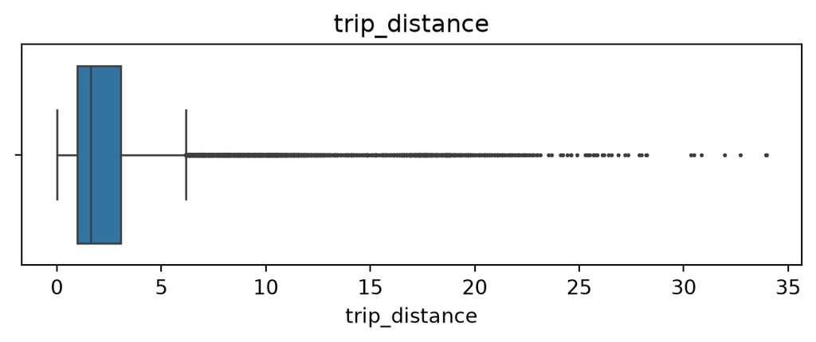

```python
# Create box plot of trip_distance
plt.figure(figsize=(7,2))
plt.title('trip_distance')
sns.boxplot(data=None, x=df['trip_distance'], fliersize=1);
```

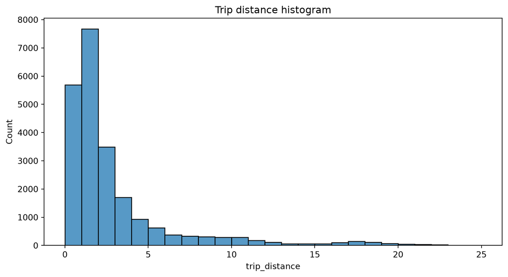

```python
# Create histogram of trip_distance
plt.figure(figsize=(10,5))
sns.histplot(df['trip_distance'], bins=range(0,26,1))
plt.title('Trip distance histogram');
```

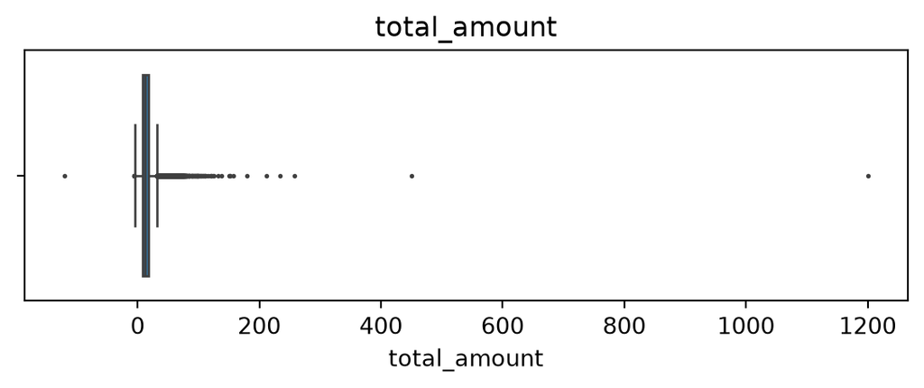

```python
# Create box plot of total_amount
plt.figure(figsize=(7,2))
plt.title('total_amount')
sns.boxplot(x=df['total_amount'], fliersize=1);
```

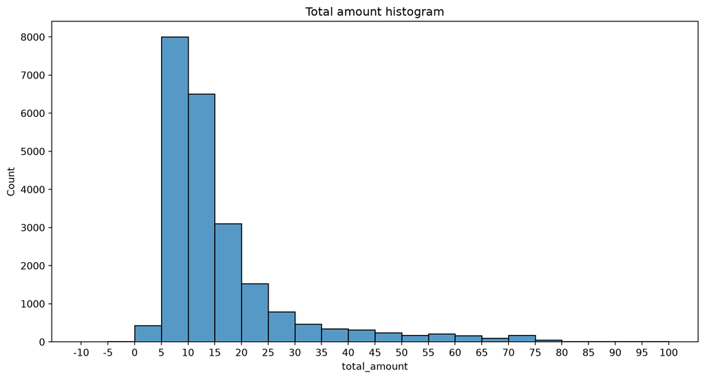

```python
# Create histogram of total_amount
plt.figure(figsize=(12,6))
ax = sns.histplot(df['total_amount'], bins=range(-10,101,5))
ax.set_xticks(range(-10,101,5))
ax.set_xticklabels(range(-10,101,5))
plt.title('Total amount histogram');
```

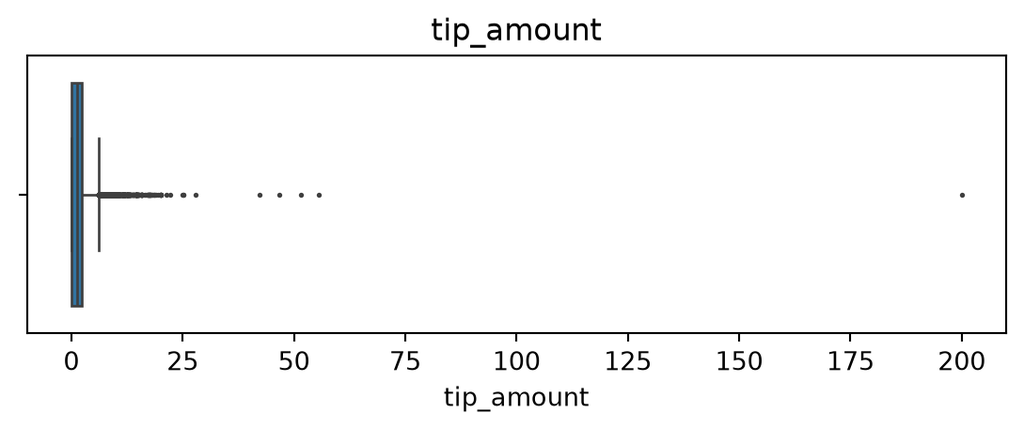

```python
# Create box plot of tip_amount
plt.figure(figsize=(7,2))
plt.title('tip_amount')
sns.boxplot(x=df['tip_amount'], fliersize=1);
```

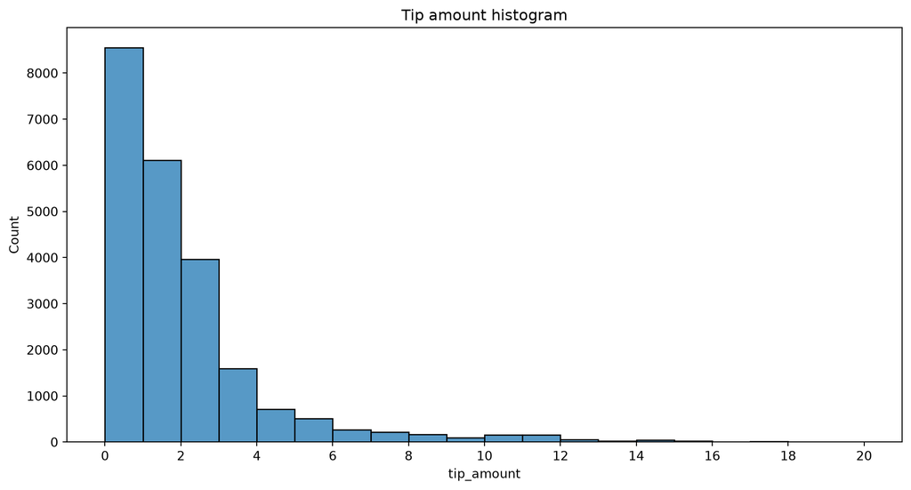

```python
# Create histogram of tip_amount
plt.figure(figsize=(12,6))
ax = sns.histplot(df['tip_amount'], bins=range(0,21,1))
ax.set_xticks(range(0,21,2))
ax.set_xticklabels(range(0,21,2))
plt.title('Tip amount histogram');
```

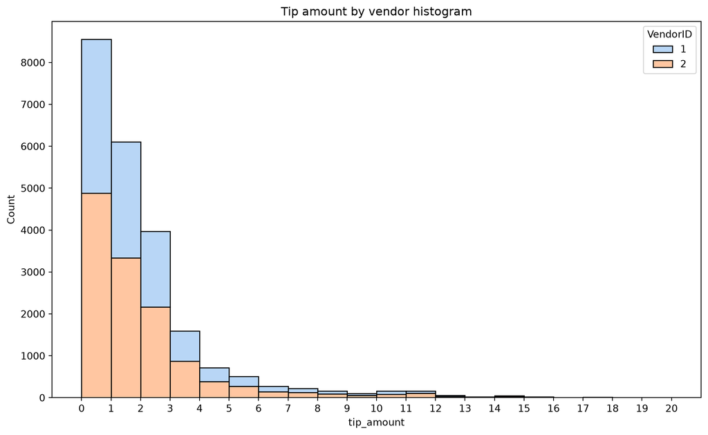

```python
# Create histogram of tip_amount by vendor
plt.figure(figsize=(12,7))
ax = sns.histplot(data=df, x='tip_amount', bins=range(0,21,1),
                  hue='VendorID',
                  multiple='stack',
                  palette='pastel')
ax.set_xticks(range(0,21,1))
ax.set_xticklabels(range(0,21,1))
plt.title('Tip amount by vendor histogram');
```

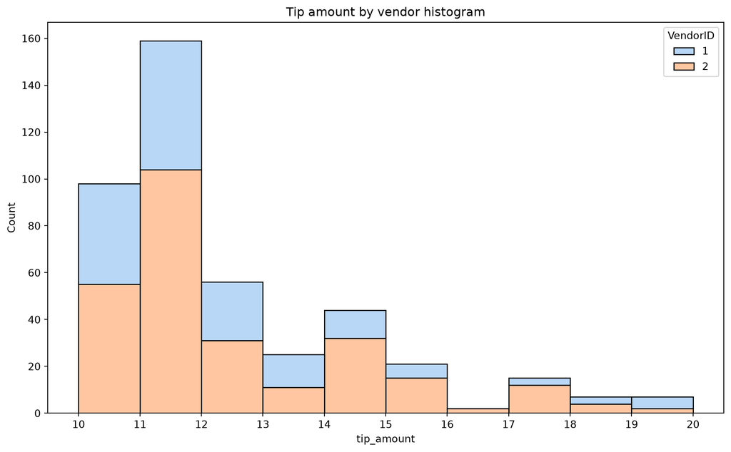

```python
# Create histogram of tip_amount by vendor for tips > $10
tips_over_ten = df[df['tip_amount'] > 10]
plt.figure(figsize=(12,7))
ax = sns.histplot(data=tips_over_ten, x='tip_amount', bins=range(10,21,1),
                  hue='VendorID',
                  multiple='stack',
                  palette='pastel')
ax.set_xticks(range(10,21,1))
ax.set_xticklabels(range(10,21,1))
plt.title('Tip amount by vendor histogram');
```

```python
df['passenger_count'].value_counts()
```

```
passenger_count
1    16117
2     3305
5     1143
3      953
6      693
4      455
0       33
Name: count, dtype: int64
```

```python
# compute mean tip by passenger_count
mean_tips_by_passenger_count = df.groupby('passenger_count', as_index=False)['tip_amount'].mean()
mean_tips_by_passenger_count
```

|  | passenger_count | tip_amount |
| --- | --- | --- |
| 0 | 0 | 2.135758 |
| 1 | 1 | 1.848920 |
| 2 | 2 | 1.856378 |
| 3 | 3 | 1.716768 |
| 4 | 4 | 1.530264 |
| 5 | 5 | 1.873185 |
| 6 | 6 | 1.720260 |

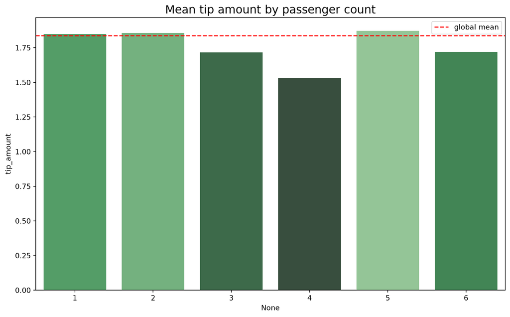

```python
# Create bar plot for mean tips by passenger count
data = mean_tips_by_passenger_count.tail(-1)
pal = sns.color_palette("Greens_d", len(data))
rank = data['tip_amount'].argsort().argsort()
plt.figure(figsize=(12,7))
ax = sns.barplot(x=data.index,
            y=data['tip_amount'],
            palette=np.array(pal[::-1])[rank])
ax.axhline(df['tip_amount'].mean(), ls='--', color='red', label='global mean')
ax.legend()
plt.title('Mean tip amount by passenger count', fontsize=16);
```

```python
# Create a month column
df['month'] = df['tpep_pickup_datetime'].dt.month_name()
# Create a day column
df['day'] = df['tpep_pickup_datetime'].dt.day_name()
```

```python
# Get total number of rides for each month
monthly_rides = df['month'].value_counts()
monthly_rides
```

```
month
March        2049
October      2027
April        2019
May          2013
January      1997
June         1964
December     1863
November     1843
February     1769
September    1734
August       1724
July         1697
Name: count, dtype: int64
```

```python
# Reorder the monthly ride list so months go in order
month_order = ['January', 'February', 'March', 'April', 'May', 'June', 'July',
         'August', 'September', 'October', 'November', 'December']

monthly_rides = monthly_rides.reindex(index=month_order)
monthly_rides
```

```
month
January      1997
February     1769
March        2049
April        2019
May          2013
June         1964
July         1697
August       1724
September    1734
October      2027
November     1843
December     1863
Name: count, dtype: int64
```

```python
# Show the index
monthly_rides.index
```

```
Index(['January', 'February', 'March', 'April', 'May', 'June', 'July',
       'August', 'September', 'October', 'November', 'December'],
      dtype='str', name='month')
```

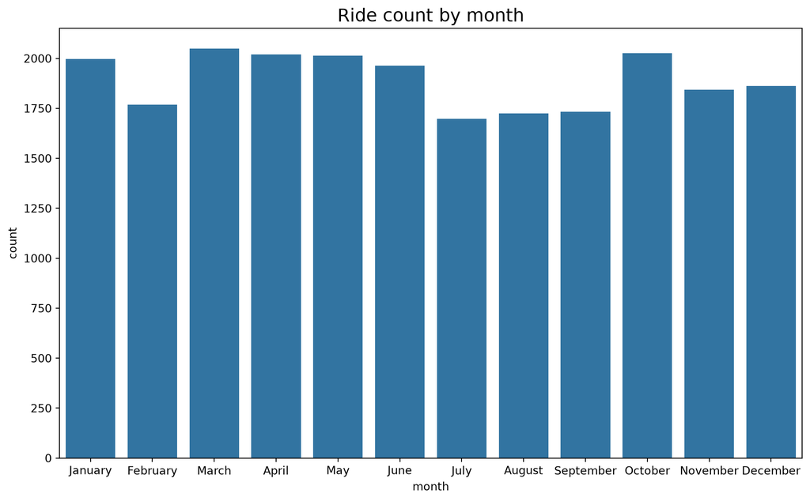

```python
# Create a bar plot of total rides per month
plt.figure(figsize=(12,7))
ax = sns.barplot(x=monthly_rides.index, y=monthly_rides)
ax.set_xticklabels(month_order)
plt.title('Ride count by month', fontsize=16);
```

```python
# Repeat the above process, this time for rides by day
daily_rides = df['day'].value_counts()
day_order = ['Monday', 'Tuesday', 'Wednesday', 'Thursday', 'Friday', 'Saturday', 'Sunday']
daily_rides = daily_rides.reindex(index=day_order)
daily_rides
```

```
day
Monday       2931
Tuesday      3198
Wednesday    3390
Thursday     3402
Friday       3413
Saturday     3367
Sunday       2998
Name: count, dtype: int64
```

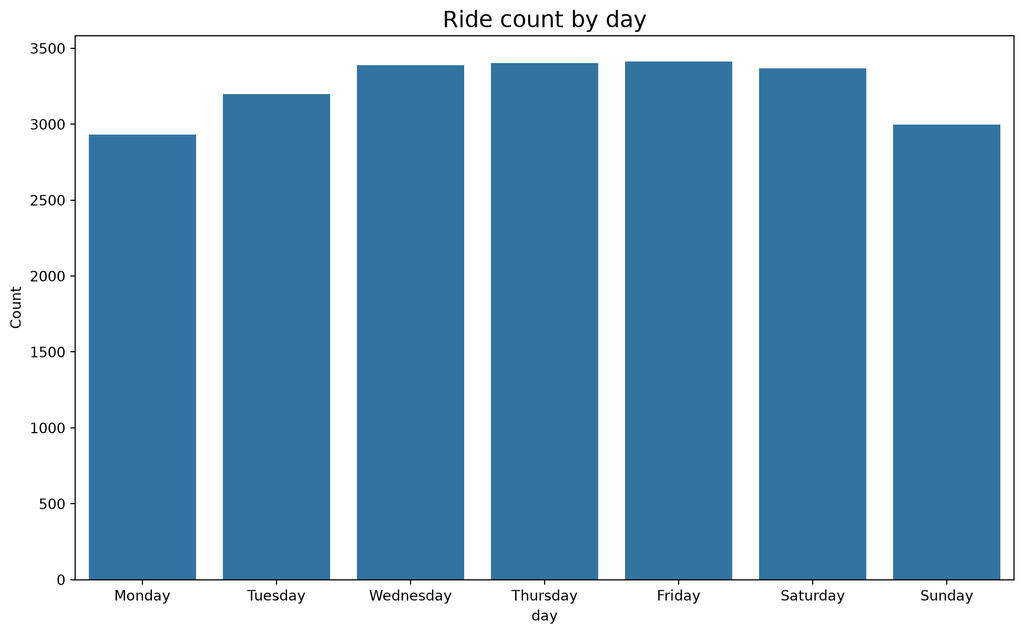

```python
# Create bar plot for ride count by day
plt.figure(figsize=(12,7))
ax = sns.barplot(x=daily_rides.index, y=daily_rides)
ax.set_xticklabels(day_order)
ax.set_ylabel('Count')
plt.title('Ride count by day', fontsize=16);
```

```python
# Repeat the process, this time for total revenue by day
day_order = ['Monday', 'Tuesday', 'Wednesday', 'Thursday', 'Friday', 'Saturday', 'Sunday']

# Replace the failing call with an aggregation on the numeric column only
total_amount_day = df.groupby('day', as_index=False)['total_amount'].sum().set_index('day').reindex(day_order)

# return the object (useful in a notebook)
total_amount_day
```

| day | total_amount |
| --- | --- |
| Monday | 49574.37 |
| Tuesday | 52527.14 |
| Wednesday | 55310.47 |
| Thursday | 57181.91 |
| Friday | 55818.74 |
| Saturday | 51195.40 |
| Sunday | 48624.06 |

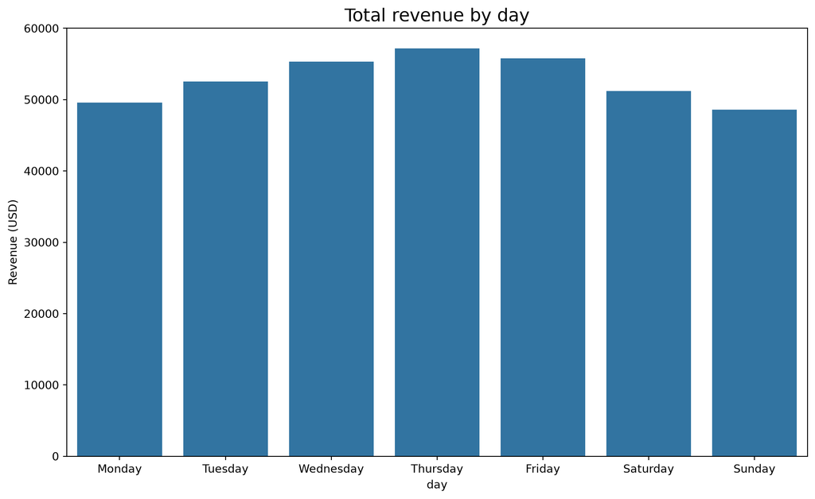

```python
# Create bar plot of total revenue by day
plt.figure(figsize=(12,7))
ax = sns.barplot(x=total_amount_day.index, y=total_amount_day['total_amount'])
ax.set_xticklabels(day_order)
ax.set_ylabel('Revenue (USD)')
plt.title('Total revenue by day', fontsize=16);
```

```python
# Repeat the process, this time for total revenue by month
# Aggregate only the numeric column to avoid datetime sum errors
total_amount_month = (
    df.groupby('month', as_index=False)['total_amount']
    .sum()
    .set_index('month')
    .reindex(month_order)
)

# return the object (useful in a notebook)
total_amount_month
```

| month | total_amount |
| --- | --- |
| January | 31735.25 |
| February | 28937.89 |
| March | 33085.89 |
| April | 32012.54 |
| May | 33828.58 |
| June | 32920.52 |
| July | 26617.64 |
| August | 27759.56 |
| September | 28206.38 |
| October | 33065.83 |
| November | 30800.44 |
| December | 31261.57 |

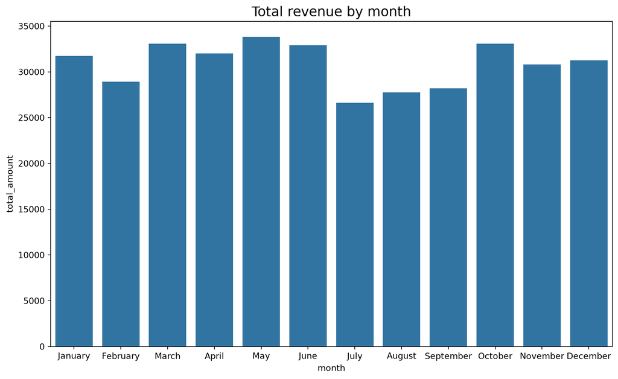

```python
# Create a bar plot of total revenue by month
plt.figure(figsize=(12,7))
ax = sns.barplot(x=total_amount_month.index, y=total_amount_month['total_amount'])
plt.title('Total revenue by month', fontsize=16);
```

We can visualize the data using Tableau to create interactive dashboards and visualizations. This will allow us to explore the data further and identify any additional patterns or insights that may be useful for building our predictive model.

Use this [Tableau](https://docs.google.com/document/d/1pcfUlttD2Y_a9A4VrKPzikZWCAfFLsBAhuKuomjcUjA/template/preview#heading=h.8983o7y9d2y2):

```python
# Get number of unique drop-off location IDs
df['DOLocationID'].nunique()
```

```
216
```

```python
# Calculate the mean trip distance for each drop-off location (aggregate numeric column only)
distance_by_dropoff = (
    df.groupby('DOLocationID', as_index=False)['trip_distance']
    .mean()
    .set_index('DOLocationID')
    .sort_values('trip_distance', ascending=True)
)

# return the object
distance_by_dropoff
```

| DOLocationID | trip_distance |
| --- | --- |
| 207 | 1.200000 |
| 193 | 1.390556 |
| 237 | 1.555494 |
| 234 | 1.727806 |
| 137 | 1.818852 |
| ... | ... |
| 51 | 17.310000 |
| 11 | 17.945000 |
| 210 | 20.500000 |
| 29 | 21.650000 |
| 23 | 24.275000 |

216 rows × 1 columns

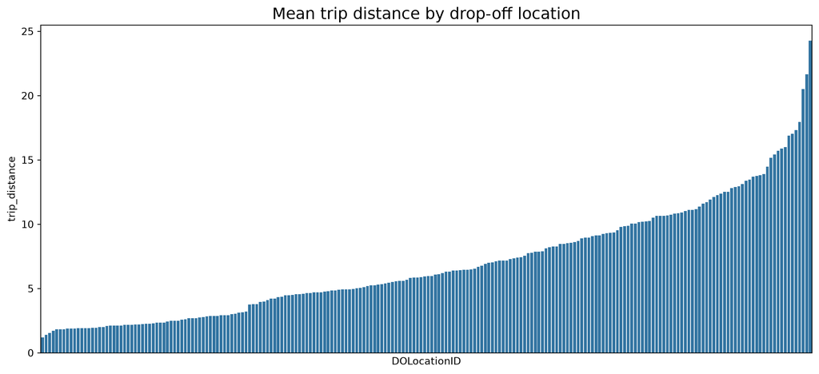

```python
# Create a bar plot of mean trip distances by drop-off location in ascending order by distance
plt.figure(figsize=(14,6))
ax = sns.barplot(x=distance_by_dropoff.index,
                 y=distance_by_dropoff['trip_distance'],
                 order=distance_by_dropoff.index)
ax.set_xticklabels([])
ax.set_xticks([])
plt.title('Mean trip distance by drop-off location', fontsize=16);
```

This plot presents a characteristic curve related to the cumulative density function of a normal distribution. In other words, it indicates that the drop-off points are relatively evenly distributed over the terrain. This is good to know, because geographic coordinates were not included in this dataset, so there was no obvious way to test for the distibution of locations.

To confirm this conclusion, consider the following experiment:

Create a sample of coordinates from a normal distribution—in this case 1,500 pairs of points from a normal distribution with a mean of 10 and a standard deviation of 5

Calculate the distance between each pair of coordinates Group the coordinates by endpoint and calculate the mean distance between that endpoint and all other points it was paired with

Plot the mean distance for each unique endpoint

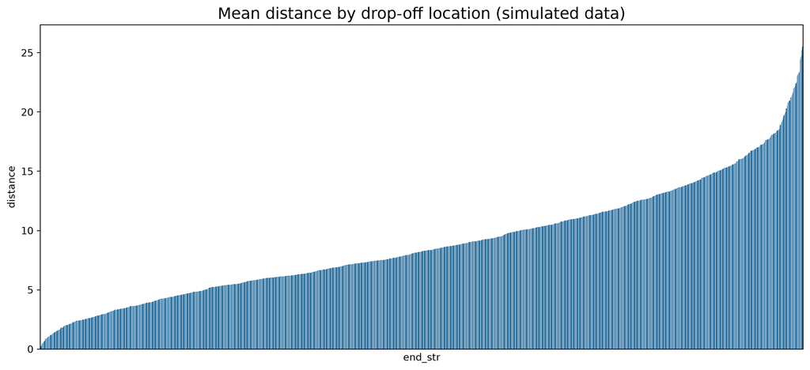

```python
# 1. Generate random points on a 2D plane from a normal distribution
test = np.round(np.random.normal(10, 5, (3000, 2)), 1)
midway = int(len(test)/2)  # Calculate midpoint of the array of coordinates
start = test[:midway]      # Isolate first half of array ("pick-up locations")
end = test[midway:]        # Isolate second half of array ("drop-off locations")

# 2. Calculate Euclidean distances between points in first half and second half of array
distances = (start - end)**2
distances = distances.sum(axis=-1)
distances = np.sqrt(distances)

# 3. Group the coordinates by "drop-off location", compute mean distance
test_df = pd.DataFrame({'start': [tuple(x) for x in start.tolist()],
                   'end': [tuple(x) for x in end.tolist()],
                   'distance': distances})

# Convert tuple endpoints to a string key to avoid MultiIndex issues
test_df['end_str'] = test_df['end'].apply(lambda t: f"{t[0]:.1f},{t[1]:.1f}")

data = test_df.groupby('end_str', as_index=False)['distance'].mean()
data = data.sort_values(by='distance')

# 4. Plot the mean distance between each endpoint ("drop-off location") and all points it connected to
plt.figure(figsize=(14,6))
ax = sns.barplot(x=data['end_str'],
                 y=data['distance'],
                 order=data['end_str'])
ax.set_xticklabels([])
ax.set_xticks([])
plt.title('Mean distance by drop-off location (simulated data)', fontsize=16);
```

This confirms our earlier conclusion that the drop-off locations are relatively evenly distributed over the terrain, as the plot shows a similar characteristic curve to the previous one.

The curve described by this graph is nearly identical to that of the mean distance traveled by each taxi ride to each drop-off location. This reveals that the drop-off locations in the taxi dataset are evenly distributed geographically. Note, however, that this does not mean that there was an even distrubtion of rides to each drop-off point. Examine this next.

First, check whether the drop-off locations IDs are consecutively numbered. For instance, does it go 1, 2, 3, 4…, or are some numbers missing (e.g., 1, 3, 4…). If numbers aren’t all consecutive, the histogram will look like some locations have very few or no rides when in reality there’s no bar because there’s no location.

```python
# Check if all drop-off locations are consecutively numbered
df['DOLocationID'].max() - len(set(df['DOLocationID']))
```

```
np.int64(49)
```

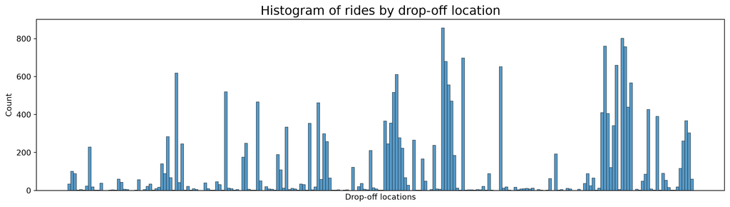

```python
plt.figure(figsize=(16,4))
# DOLocationID column is numeric, so sort in ascending order
sorted_dropoffs = df['DOLocationID'].sort_values()
# Convert to string
sorted_dropoffs = sorted_dropoffs.astype('str')
# Plot
sns.histplot(sorted_dropoffs, bins=range(0, df['DOLocationID'].max()+1, 1))
plt.xticks([])
plt.xlabel('Drop-off locations')
plt.title('Histogram of rides by drop-off location', fontsize=16);
```

The histogram shows that some drop-off locations have significantly more rides than others. This indicates that certain areas are more popular destinations for taxi rides, which could be due to factors such as population density, commercial activity, or tourist attractions.

```python
df['trip_duration'] = (df['tpep_dropoff_datetime']-df['tpep_pickup_datetime'])
```

```python
df.head(10)
```

|  | Unnamed: 0 | VendorID | tpep_pickup_datetime | tpep_dropoff_datetime | passenger_count | trip_distance | RatecodeID | store_and_fwd_flag | PULocationID | DOLocationID | ... | fare_amount | extra | mta_tax | tip_amount | tolls_amount | improvement_surcharge | total_amount | month | day | trip_duration |
| --- | --- | --- | --- | --- | --- | --- | --- | --- | --- | --- | --- | --- | --- | --- | --- | --- | --- | --- | --- | --- | --- |
| 0 | 24870114 | 2 | 2017-03-25 08:55:43 | 2017-03-25 09:09:47 | 6 | 3.34 | 1 | N | 100 | 231 | ... | 13.0 | 0.0 | 0.5 | 2.76 | 0.0 | 0.3 | 16.56 | March | Saturday | 0 days 00:14:04 |
| 1 | 35634249 | 1 | 2017-04-11 14:53:28 | 2017-04-11 15:19:58 | 1 | 1.80 | 1 | N | 186 | 43 | ... | 16.0 | 0.0 | 0.5 | 4.00 | 0.0 | 0.3 | 20.80 | April | Tuesday | 0 days 00:26:30 |
| 2 | 106203690 | 1 | 2017-12-15 07:26:56 | 2017-12-15 07:34:08 | 1 | 1.00 | 1 | N | 262 | 236 | ... | 6.5 | 0.0 | 0.5 | 1.45 | 0.0 | 0.3 | 8.75 | December | Friday | 0 days 00:07:12 |
| 3 | 38942136 | 2 | 2017-05-07 13:17:59 | 2017-05-07 13:48:14 | 1 | 3.70 | 1 | N | 188 | 97 | ... | 20.5 | 0.0 | 0.5 | 6.39 | 0.0 | 0.3 | 27.69 | May | Sunday | 0 days 00:30:15 |
| 4 | 30841670 | 2 | 2017-04-15 23:32:20 | 2017-04-15 23:49:03 | 1 | 4.37 | 1 | N | 4 | 112 | ... | 16.5 | 0.5 | 0.5 | 0.00 | 0.0 | 0.3 | 17.80 | April | Saturday | 0 days 00:16:43 |
| 5 | 23345809 | 2 | 2017-03-25 20:34:11 | 2017-03-25 20:42:11 | 6 | 2.30 | 1 | N | 161 | 236 | ... | 9.0 | 0.5 | 0.5 | 2.06 | 0.0 | 0.3 | 12.36 | March | Saturday | 0 days 00:08:00 |
| 6 | 37660487 | 2 | 2017-05-03 19:04:09 | 2017-05-03 20:03:47 | 1 | 12.83 | 1 | N | 79 | 241 | ... | 47.5 | 1.0 | 0.5 | 9.86 | 0.0 | 0.3 | 59.16 | May | Wednesday | 0 days 00:59:38 |
| 7 | 69059411 | 2 | 2017-08-15 17:41:06 | 2017-08-15 18:03:05 | 1 | 2.98 | 1 | N | 237 | 114 | ... | 16.0 | 1.0 | 0.5 | 1.78 | 0.0 | 0.3 | 19.58 | August | Tuesday | 0 days 00:21:59 |
| 8 | 8433159 | 2 | 2017-02-04 16:17:07 | 2017-02-04 16:29:14 | 1 | 1.20 | 1 | N | 234 | 249 | ... | 9.0 | 0.0 | 0.5 | 0.00 | 0.0 | 0.3 | 9.80 | February | Saturday | 0 days 00:12:07 |
| 9 | 95294817 | 1 | 2017-11-10 15:20:29 | 2017-11-10 15:40:55 | 1 | 1.60 | 1 | N | 239 | 237 | ... | 13.0 | 0.0 | 0.5 | 2.75 | 0.0 | 0.3 | 16.55 | November | Friday | 0 days 00:20:26 |

10 rows × 21 columns

#### 2.3.1.1 Conclusion of EDA

In conclusion, the exploratory data analysis (EDA) of the taxi cab dataset has provided valuable insights into the relationships between various variables and identified potential issues and outliers. Key findings include:

- The total_amount and trip_distance variables are likely to be the most important predictors for building a predictive model for taxi ride fares.
- Other variables such as passenger_count, payment_type, and VendorID may also be relevant for the model.
- The distribution of drop-off locations is relatively even geographically, but certain locations have significantly more rides than others, indicating popular destinations.
- The analysis of tip amounts revealed differences between vendors and passenger counts, which could inform strategies for maximizing tips.

These insights will guide the next steps in data cleaning, feature engineering, and model building to develop an accurate and reliable predictive model for taxi ride fares.

### 2.3.2 Statistical analysis

The purpose of this project is to demostrate knowledge of how to prepare, create, and analyze A/B tests. Your A/B test results should aim to find ways to generate more revenue for taxi cab drivers.

Note: For the purpose of this exercise, assume that the sample data comes from an experiment in which customers are randomly selected and divided into two groups: 1) customers who are required to pay with credit card, 2) customers who are required to pay with cash. Without this assumption, we cannot draw causal conclusions about how payment method affects fare amount.

The goal is to apply descriptive statistics and hypothesis testing in Python. The goal for this A/B test is to sample data and analyze whether there is a relationship between payment type and fare amount. For example: discover if customers who use credit cards pay higher fare amounts than customers who use cash.

**This activity has three parts:**

*Part 1: Imports and data loading*

What data packages will be necessary for hypothesis testing?

*Part 2: Conduct EDA and hypothesis testing*

How did computing descriptive statistics help you analyze your data?

How did you formulate your null hypothesis and alternative hypothesis?

*Part 3: Communicate insights with stakeholders*

What key business insight(s) emerged from your A/B test?

What business recommendations do you propose based on your results?

```python
import pandas as pd
from scipy import stats
```

```python
taxi_data = "/Users/macbookpro/Training/COURSERA_Data_Analytics/COURSERA_Data_Analytics/Data/2017_Yellow_Taxi_Trip_Data.csv"
taxi_data = pd.read_csv(taxi_data, index_col=0)
```

In general, descriptive statistics are useful because they let you quickly explore and understand large amounts of data. In this case, computing descriptive statistics helps you quickly compare the average total fare amount among different payment types.

#### 2.3.2.1 Use descriptive statistics to conduct Exploratory Data Analysis (EDA).

```python
# descriptive stats code for EDA
taxi_data.describe(include='all')
```

|  | VendorID | tpep_pickup_datetime | tpep_dropoff_datetime | passenger_count | trip_distance | RatecodeID | store_and_fwd_flag | PULocationID | DOLocationID | payment_type | fare_amount | extra | mta_tax | tip_amount | tolls_amount | improvement_surcharge | total_amount |
| --- | --- | --- | --- | --- | --- | --- | --- | --- | --- | --- | --- | --- | --- | --- | --- | --- | --- |
| count | 22699.000000 | 22699 | 22699 | 22699.000000 | 22699.000000 | 22699.000000 | 22699 | 22699.000000 | 22699.000000 | 22699.000000 | 22699.000000 | 22699.000000 | 22699.000000 | 22699.000000 | 22699.000000 | 22699.000000 | 22699.000000 |
| unique | NaN | 22687 | 22688 | NaN | NaN | NaN | 2 | NaN | NaN | NaN | NaN | NaN | NaN | NaN | NaN | NaN | NaN |
| top | NaN | 06/20/2017 6:57:39 PM | 04/17/2017 7:39:36 AM | NaN | NaN | NaN | N | NaN | NaN | NaN | NaN | NaN | NaN | NaN | NaN | NaN | NaN |
| freq | NaN | 2 | 2 | NaN | NaN | NaN | 22600 | NaN | NaN | NaN | NaN | NaN | NaN | NaN | NaN | NaN | NaN |
| mean | 1.556236 | NaN | NaN | 1.642319 | 2.913313 | 1.043394 | NaN | 162.412353 | 161.527997 | 1.336887 | 13.026629 | 0.333275 | 0.497445 | 1.835781 | 0.312542 | 0.299551 | 16.310502 |
| std | 0.496838 | NaN | NaN | 1.285231 | 3.653171 | 0.708391 | NaN | 66.633373 | 70.139691 | 0.496211 | 13.243791 | 0.463097 | 0.039465 | 2.800626 | 1.399212 | 0.015673 | 16.097295 |
| min | 1.000000 | NaN | NaN | 0.000000 | 0.000000 | 1.000000 | NaN | 1.000000 | 1.000000 | 1.000000 | -120.000000 | -1.000000 | -0.500000 | 0.000000 | 0.000000 | -0.300000 | -120.300000 |
| 25% | 1.000000 | NaN | NaN | 1.000000 | 0.990000 | 1.000000 | NaN | 114.000000 | 112.000000 | 1.000000 | 6.500000 | 0.000000 | 0.500000 | 0.000000 | 0.000000 | 0.300000 | 8.750000 |
| 50% | 2.000000 | NaN | NaN | 1.000000 | 1.610000 | 1.000000 | NaN | 162.000000 | 162.000000 | 1.000000 | 9.500000 | 0.000000 | 0.500000 | 1.350000 | 0.000000 | 0.300000 | 11.800000 |
| 75% | 2.000000 | NaN | NaN | 2.000000 | 3.060000 | 1.000000 | NaN | 233.000000 | 233.000000 | 2.000000 | 14.500000 | 0.500000 | 0.500000 | 2.450000 | 0.000000 | 0.300000 | 17.800000 |
| max | 2.000000 | NaN | NaN | 6.000000 | 33.960000 | 99.000000 | NaN | 265.000000 | 265.000000 | 4.000000 | 999.990000 | 4.500000 | 0.500000 | 200.000000 | 19.100000 | 0.300000 | 1200.290000 |

```python
taxi_data.groupby('payment_type')['fare_amount'].mean()
```

```
payment_type
1    13.429748
2    12.213546
3    12.186116
4     9.913043
Name: fare_amount, dtype: float64
```

#### 2.3.2.2 Hypothesis formulation:

**𝐻0**

There is no difference in the average fare amount between customers who use credit cards and customers who use cash.

**𝐻𝐴**

There is a difference in the average fare amount between customers who use credit cards and customers who use cash.

```python
#hypothesis test, A/B test
#significance level

credit_card = taxi_data[taxi_data['payment_type'] == 1]['fare_amount']
cash = taxi_data[taxi_data['payment_type'] == 2]['fare_amount']
stats.ttest_ind(a=credit_card, b=cash, equal_var=False)
```

```
TtestResult(statistic=np.float64(6.866800855655361), pvalue=np.float64(6.797387473031004e-12), df=np.float64(16675.48547403633))
```

The p-value is less than 0.05, so we reject the null hypothesis. This means that there is a statistically significant difference in the average fare amount between customers who use credit cards and customers who use cash.

Based on the results of the A/B test, we can conclude that payment type does have an effect on fare amount. Specifically, customers who use credit cards tend to pay higher fare amounts than those who use cash.

Therefore, we recommend that taxi cab drivers encourage customers to pay with credit cards whenever possible. This could be done by prominently displaying credit card payment options in the taxi, offering incentives for credit card payments, or partnering with credit card companies to offer discounts or rewards for using their cards.

### 2.3.3 Build a multiple regression model

The purpose of this project is to demostrate knowledge of EDA and a multiple linear regression model.

The goal is to build a multiple linear regression model and evaluate the model.

*This activity has three parts:*

**Part 1: EDA & Checking Model Assumptions**

What are some purposes of EDA before constructing a multiple linear regression model?

**Part 2: Model Building and evaluation**

What resources do you find yourself using as you complete this stage?

**Part 3: Interpreting Model Results**

What key insights emerged from your model(s)?

What business recommendations do you propose based on the models built?

```python
# Imports
# Packages for numerics + dataframes
import pandas as pd
import numpy as np

# Packages for visualization
import matplotlib.pyplot as plt
import seaborn as sns

# Packages for date conversions for calculating trip durations
from datetime import datetime
from datetime import date
from datetime import timedelta

# Packages for OLS, MLR, confusion matrix
from sklearn.preprocessing import StandardScaler
from sklearn.model_selection import train_test_split
import sklearn.metrics as metrics # For confusion matrix
from sklearn.linear_model import LinearRegression
from sklearn.metrics import mean_absolute_error,r2_score,mean_squared_error
```

```python
df0="/Users/macbookpro/Training/COURSERA_Data_Analytics/COURSERA_Data_Analytics/Data/2017_Yellow_Taxi_Trip_Data.csv"
df0 = pd.read_csv(df0)
```

```python
# Start with `.shape` and `.info()`

# Keep `df0` as the original dataframe and create a copy (df) where changes will go
# Can revert `df` to `df0` if needed down the line
df = df0.copy()

# Display the dataset's shape
print(df.shape)

# Display basic info about the dataset
df.info()
```

```
(22699, 18)
<class 'pandas.DataFrame'>
RangeIndex: 22699 entries, 0 to 22698
Data columns (total 18 columns):
 #   Column                 Non-Null Count  Dtype
---  ------                 --------------  -----
 0   Unnamed: 0             22699 non-null  int64
 1   VendorID               22699 non-null  int64
 2   tpep_pickup_datetime   22699 non-null  str
 3   tpep_dropoff_datetime  22699 non-null  str
 4   passenger_count        22699 non-null  int64
 5   trip_distance          22699 non-null  float64
 6   RatecodeID             22699 non-null  int64
 7   store_and_fwd_flag     22699 non-null  str
 8   PULocationID           22699 non-null  int64
 9   DOLocationID           22699 non-null  int64
 10  payment_type           22699 non-null  int64
 11  fare_amount            22699 non-null  float64
 12  extra                  22699 non-null  float64
 13  mta_tax                22699 non-null  float64
 14  tip_amount             22699 non-null  float64
 15  tolls_amount           22699 non-null  float64
 16  improvement_surcharge  22699 non-null  float64
 17  total_amount           22699 non-null  float64
dtypes: float64(8), int64(7), str(3)
memory usage: 3.1 MB
```

```python
# Check for missing data and duplicates using .isna() and .drop_duplicates()
### YOUR CODE HERE ###

# Check for duplicates
print('Shape of dataframe:', df.shape)
print('Shape of dataframe with duplicates dropped:', df.drop_duplicates().shape)

# Check for missing values in dataframe
print('Total count of missing values:', df.isna().sum().sum())

# Display missing values per column in dataframe
print('Missing values per column:')
df.isna().sum()
```

```
Shape of dataframe: (22699, 18)
Shape of dataframe with duplicates dropped: (22699, 18)
Total count of missing values: 0
Missing values per column:
```

```
Unnamed: 0               0
VendorID                 0
tpep_pickup_datetime     0
tpep_dropoff_datetime    0
passenger_count          0
trip_distance            0
RatecodeID               0
store_and_fwd_flag       0
PULocationID             0
DOLocationID             0
payment_type             0
fare_amount              0
extra                    0
mta_tax                  0
tip_amount               0
tolls_amount             0
improvement_surcharge    0
total_amount             0
dtype: int64
```

```python
# Display descriptive stats about the data
df.describe()
```

|  | Unnamed: 0 | VendorID | passenger_count | trip_distance | RatecodeID | PULocationID | DOLocationID | payment_type | fare_amount | extra | mta_tax | tip_amount | tolls_amount | improvement_surcharge | total_amount |
| --- | --- | --- | --- | --- | --- | --- | --- | --- | --- | --- | --- | --- | --- | --- | --- |
| count | 2.269900e+04 | 22699.000000 | 22699.000000 | 22699.000000 | 22699.000000 | 22699.000000 | 22699.000000 | 22699.000000 | 22699.000000 | 22699.000000 | 22699.000000 | 22699.000000 | 22699.000000 | 22699.000000 | 22699.000000 |
| mean | 5.675849e+07 | 1.556236 | 1.642319 | 2.913313 | 1.043394 | 162.412353 | 161.527997 | 1.336887 | 13.026629 | 0.333275 | 0.497445 | 1.835781 | 0.312542 | 0.299551 | 16.310502 |
| std | 3.274493e+07 | 0.496838 | 1.285231 | 3.653171 | 0.708391 | 66.633373 | 70.139691 | 0.496211 | 13.243791 | 0.463097 | 0.039465 | 2.800626 | 1.399212 | 0.015673 | 16.097295 |
| min | 1.212700e+04 | 1.000000 | 0.000000 | 0.000000 | 1.000000 | 1.000000 | 1.000000 | 1.000000 | -120.000000 | -1.000000 | -0.500000 | 0.000000 | 0.000000 | -0.300000 | -120.300000 |
| 25% | 2.852056e+07 | 1.000000 | 1.000000 | 0.990000 | 1.000000 | 114.000000 | 112.000000 | 1.000000 | 6.500000 | 0.000000 | 0.500000 | 0.000000 | 0.000000 | 0.300000 | 8.750000 |
| 50% | 5.673150e+07 | 2.000000 | 1.000000 | 1.610000 | 1.000000 | 162.000000 | 162.000000 | 1.000000 | 9.500000 | 0.000000 | 0.500000 | 1.350000 | 0.000000 | 0.300000 | 11.800000 |
| 75% | 8.537452e+07 | 2.000000 | 2.000000 | 3.060000 | 1.000000 | 233.000000 | 233.000000 | 2.000000 | 14.500000 | 0.500000 | 0.500000 | 2.450000 | 0.000000 | 0.300000 | 17.800000 |
| max | 1.134863e+08 | 2.000000 | 6.000000 | 33.960000 | 99.000000 | 265.000000 | 265.000000 | 4.000000 | 999.990000 | 4.500000 | 0.500000 | 200.000000 | 19.100000 | 0.300000 | 1200.290000 |

```python
# Check the format of the data
df['tpep_dropoff_datetime'][0]
```

```
'03/25/2017 9:09:47 AM'
```

```python
# Convert datetime columns to datetime
# Display data types of `tpep_pickup_datetime`, `tpep_dropoff_datetime`
print('Data type of tpep_pickup_datetime:', df['tpep_pickup_datetime'].dtype)
print('Data type of tpep_dropoff_datetime:', df['tpep_dropoff_datetime'].dtype)

# Convert `tpep_pickup_datetime` to datetime format
df['tpep_pickup_datetime'] = pd.to_datetime(df['tpep_pickup_datetime'], format='%m/%d/%Y %I:%M:%S %p')

# Convert `tpep_dropoff_datetime` to datetime format
df['tpep_dropoff_datetime'] = pd.to_datetime(df['tpep_dropoff_datetime'], format='%m/%d/%Y %I:%M:%S %p')

# Display data types of `tpep_pickup_datetime`, `tpep_dropoff_datetime`
print('Data type of tpep_pickup_datetime:', df['tpep_pickup_datetime'].dtype)
print('Data type of tpep_dropoff_datetime:', df['tpep_dropoff_datetime'].dtype)

df.head(3)
```

```
Data type of tpep_pickup_datetime: str
Data type of tpep_dropoff_datetime: str
Data type of tpep_pickup_datetime: datetime64[us]
Data type of tpep_dropoff_datetime: datetime64[us]
```

|  | Unnamed: 0 | VendorID | tpep_pickup_datetime | tpep_dropoff_datetime | passenger_count | trip_distance | RatecodeID | store_and_fwd_flag | PULocationID | DOLocationID | payment_type | fare_amount | extra | mta_tax | tip_amount | tolls_amount | improvement_surcharge | total_amount |
| --- | --- | --- | --- | --- | --- | --- | --- | --- | --- | --- | --- | --- | --- | --- | --- | --- | --- | --- |
| 0 | 24870114 | 2 | 2017-03-25 08:55:43 | 2017-03-25 09:09:47 | 6 | 3.34 | 1 | N | 100 | 231 | 1 | 13.0 | 0.0 | 0.5 | 2.76 | 0.0 | 0.3 | 16.56 |
| 1 | 35634249 | 1 | 2017-04-11 14:53:28 | 2017-04-11 15:19:58 | 1 | 1.80 | 1 | N | 186 | 43 | 1 | 16.0 | 0.0 | 0.5 | 4.00 | 0.0 | 0.3 | 20.80 |
| 2 | 106203690 | 1 | 2017-12-15 07:26:56 | 2017-12-15 07:34:08 | 1 | 1.00 | 1 | N | 262 | 236 | 1 | 6.5 | 0.0 | 0.5 | 1.45 | 0.0 | 0.3 | 8.75 |

```python
# Create `duration` column
df['duration'] = (df['tpep_dropoff_datetime'] - df['tpep_pickup_datetime'])/np.timedelta64(1,'m')
```

```python
# Outlier detection and removal
df.info()
```

```
<class 'pandas.DataFrame'>
RangeIndex: 22699 entries, 0 to 22698
Data columns (total 19 columns):
 #   Column                 Non-Null Count  Dtype
---  ------                 --------------  -----
 0   Unnamed: 0             22699 non-null  int64
 1   VendorID               22699 non-null  int64
 2   tpep_pickup_datetime   22699 non-null  datetime64[us]
 3   tpep_dropoff_datetime  22699 non-null  datetime64[us]
 4   passenger_count        22699 non-null  int64
 5   trip_distance          22699 non-null  float64
 6   RatecodeID             22699 non-null  int64
 7   store_and_fwd_flag     22699 non-null  str
 8   PULocationID           22699 non-null  int64
 9   DOLocationID           22699 non-null  int64
 10  payment_type           22699 non-null  int64
 11  fare_amount            22699 non-null  float64
 12  extra                  22699 non-null  float64
 13  mta_tax                22699 non-null  float64
 14  tip_amount             22699 non-null  float64
 15  tolls_amount           22699 non-null  float64
 16  improvement_surcharge  22699 non-null  float64
 17  total_amount           22699 non-null  float64
 18  duration               22699 non-null  float64
dtypes: datetime64[us](2), float64(9), int64(7), str(1)
memory usage: 3.3 MB
```

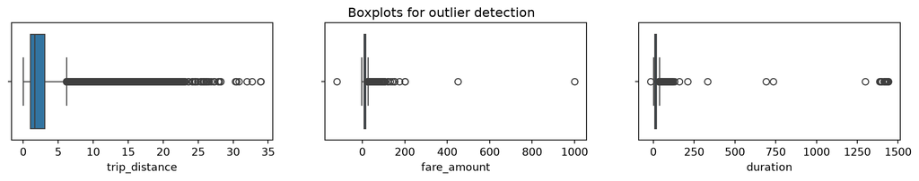

```python
fig, axes = plt.subplots(1, 3, figsize=(15, 2))
fig.suptitle('Boxplots for outlier detection')
sns.boxplot(ax=axes[0], x=df['trip_distance'])
sns.boxplot(ax=axes[1], x=df['fare_amount'])
sns.boxplot(ax=axes[2], x=df['duration'])
plt.show();
```

All three variables contain outliers. Some are extreme, but others not so much.

It’s 30 miles from the southern tip of Staten Island to the northern end of Manhattan and that’s in a straight line. With this knowledge and the distribution of the values in this column, it’s reasonable to leave these values alone and not alter them. However, the values for fare_amount and duration definitely seem to have problematic outliers on the higher end.

Probably not for the latter two, but for trip_distance it might be okay.

#### 2.3.3.1 Imputation strategy

```python
# Are trip distances of 0 bad data or very short trips rounded down?
sorted(set(df['trip_distance']))[:10]
```

```
[0.0, 0.01, 0.02, 0.03, 0.04, 0.05, 0.06, 0.07, 0.08, 0.09]
```

```python
sum(df['trip_distance']==0)
```

```
148
```

148 out of ~23,000 rides is relatively insignificant. You could impute it with a value of 0.01, but it’s unlikely to have much of an effect on the model. Therefore, the trip_distance column will remain untouched with regard to outliers.

```python
#fare_amount outliers
df['fare_amount'].describe()
```

```
count    22699.000000
mean        13.026629
std         13.243791
min       -120.000000
25%          6.500000
50%          9.500000
75%         14.500000
max        999.990000
Name: fare_amount, dtype: float64
```

The range of values in the fare_amount column is large and the extremes don’t make much sense.

Low values: Negative values are problematic. Values of zero could be legitimate if the taxi logged a trip that was immediately canceled.

High values: The maximum fare amount in this dataset is nearly $1,000, which seems very unlikely. High values for this feature can be capped based on intuition and statistics. The interquartile range (IQR) is $8. The standard formula of Q3 + (1.5 * IQR) yields $26.50. That doesn’t seem to be appropriate for the maximum fare cap. In this case, we’ll use a factor of 6, which results in a cap of $62.50.

Impute values less than $0 with 0.

```python
# Impute values less than $0 with 0
df.loc[df['fare_amount'] < 0, 'fare_amount'] = 0
df['fare_amount'].min()
```

```
np.float64(0.0)
```

```python
def outlier_imputer(column_list, iqr_factor):
    '''
    Impute upper-limit values in specified columns based on their interquartile range.

    Arguments:
        column_list: A list of columns to iterate over
        iqr_factor: A number representing x in the formula:
                    Q3 + (x * IQR). Used to determine maximum threshold,
                    beyond which a point is considered an outlier.

    The IQR is computed for each column in column_list and values exceeding
    the upper threshold for each column are imputed with the upper threshold value.
    '''
    for col in column_list:
        # Reassign minimum to zero
        df.loc[df[col] < 0, col] = 0

        # Calculate upper threshold
        q1 = df[col].quantile(0.25)
        q3 = df[col].quantile(0.75)
        iqr = q3 - q1
        upper_threshold = q3 + (iqr_factor * iqr)
        print(col)
        print('q3:', q3)
        print('upper_threshold:', upper_threshold)

        # Reassign values > threshold to threshold
        df.loc[df[col] > upper_threshold, col] = upper_threshold
        print(df[col].describe())
        print()
```

```python
outlier_imputer(['fare_amount'], 6)
```

```
fare_amount
q3: 14.5
upper_threshold: 62.5
count    22699.000000
mean        12.897913
std         10.541137
min          0.000000
25%          6.500000
50%          9.500000
75%         14.500000
max         62.500000
Name: fare_amount, dtype: float64
```

```python
df['duration'].describe()
```

```
count    22699.000000
mean        17.013777
std         61.996482
min        -16.983333
25%          6.650000
50%         11.183333
75%         18.383333
max       1439.550000
Name: duration, dtype: float64
```

```python
# Impute a 0 for any negative values
df.loc[df['duration'] < 0, 'duration'] = 0
df['duration'].min()
```

```
np.float64(0.0)
```

```python
# Impute the high outliers
outlier_imputer(['duration'], 6)
```

```
duration
q3: 18.383333333333333
upper_threshold: 88.78333333333333
count    22699.000000
mean        14.460555
std         11.947043
min          0.000000
25%          6.650000
50%         11.183333
75%         18.383333
max         88.783333
Name: duration, dtype: float64
```

```python
# Create `pickup_dropoff` column
df['pickup_dropoff'] = df['PULocationID'].astype(str) + ' ' + df['DOLocationID'].astype(str)
df['pickup_dropoff'].head(2)
```

```
0    100 231
1     186 43
Name: pickup_dropoff, dtype: str
```

```python
grouped = df.groupby('pickup_dropoff').mean(numeric_only=True)[['trip_distance']]
grouped[:5]
```

| pickup_dropoff | trip_distance |
| --- | --- |
| 1 1 | 2.433333 |
| 10 148 | 15.700000 |
| 100 1 | 16.890000 |
| 100 100 | 0.253333 |
| 100 107 | 1.180000 |

```python
# 1. Convert `grouped` to a dictionary
grouped_dict = grouped.to_dict()

# 2. Reassign to only contain the inner dictionary
grouped_dict = grouped_dict['trip_distance']
```

```python
# 1. Create a mean_distance column that is a copy of the pickup_dropoff helper column
df['mean_distance'] = df['pickup_dropoff']

# 2. Map `grouped_dict` to the `mean_distance` column
df['mean_distance'] = df['mean_distance'].map(grouped_dict)

# Confirm that it worked
df[(df['PULocationID']==100) & (df['DOLocationID']==231)][['mean_distance']]
```

|  | mean_distance |
| --- | --- |
| 0 | 3.521667 |
| 4909 | 3.521667 |
| 16636 | 3.521667 |
| 18134 | 3.521667 |
| 19761 | 3.521667 |
| 20581 | 3.521667 |

**Create mean_duration column**

Repeat the process used to create the mean_distance column to create a mean_duration column.

```python
grouped = df.groupby('pickup_dropoff').mean(numeric_only=True)[['duration']]
grouped

# Create a dictionary where keys are unique pickup_dropoffs and values are
# mean trip duration for all trips with those pickup_dropoff combos
grouped_dict = grouped.to_dict()
grouped_dict = grouped_dict['duration']

df['mean_duration'] = df['pickup_dropoff']
df['mean_duration'] = df['mean_duration'].map(grouped_dict)

# Confirm that it worked
df[(df['PULocationID']==100) & (df['DOLocationID']==231)][['mean_duration']]
```

|  | mean_duration |
| --- | --- |
| 0 | 22.847222 |
| 4909 | 22.847222 |
| 16636 | 22.847222 |
| 18134 | 22.847222 |
| 19761 | 22.847222 |
| 20581 | 22.847222 |

**Create day and month columns**

Create two new columns, day (name of day) and month (name of month) by extracting the relevant information from the tpep_pickup_datetime column.

```python
# Create 'day' col
df['day'] = df['tpep_pickup_datetime'].dt.day_name().str.lower()

# Create 'month' col
df['month'] = df['tpep_pickup_datetime'].dt.strftime('%b').str.lower()
```

**Create rush_hour column**

Define rush hour as:

Any weekday (not Saturday or Sunday) AND

Either from 06:00–10:00 or from 16:00–20:00

```python
# Create 'rush_hour' col
df['rush_hour'] = df['tpep_pickup_datetime'].dt.hour

# If day is Saturday or Sunday, impute 0 in `rush_hour` column
df.loc[df['day'].isin(['saturday', 'sunday']), 'rush_hour'] = 0
```

```python
def rush_hourizer(hour):
    if 6 <= hour['rush_hour'] < 10:
        val = 1
    elif 16 <= hour['rush_hour'] < 20:
        val = 1
    else:
        val = 0
    return val
```

```python
# Apply the `rush_hourizer()` function to the new column
#df.loc[(df.day != 'saturday') & (df.day != 'sunday'), 'rush_hour'] = df.apply(rush_hourizer, axis=1)
df.head()
```

|  | Unnamed: 0 | VendorID | tpep_pickup_datetime | tpep_dropoff_datetime | passenger_count | trip_distance | RatecodeID | store_and_fwd_flag | PULocationID | DOLocationID | ... | tolls_amount | improvement_surcharge | total_amount | duration | pickup_dropoff | mean_distance | mean_duration | day | month | rush_hour |
| --- | --- | --- | --- | --- | --- | --- | --- | --- | --- | --- | --- | --- | --- | --- | --- | --- | --- | --- | --- | --- | --- |
| 0 | 24870114 | 2 | 2017-03-25 08:55:43 | 2017-03-25 09:09:47 | 6 | 3.34 | 1 | N | 100 | 231 | ... | 0.0 | 0.3 | 16.56 | 14.066667 | 100 231 | 3.521667 | 22.847222 | saturday | mar | 0 |
| 1 | 35634249 | 1 | 2017-04-11 14:53:28 | 2017-04-11 15:19:58 | 1 | 1.80 | 1 | N | 186 | 43 | ... | 0.0 | 0.3 | 20.80 | 26.500000 | 186 43 | 3.108889 | 24.470370 | tuesday | apr | 14 |
| 2 | 106203690 | 1 | 2017-12-15 07:26:56 | 2017-12-15 07:34:08 | 1 | 1.00 | 1 | N | 262 | 236 | ... | 0.0 | 0.3 | 8.75 | 7.200000 | 262 236 | 0.881429 | 7.250000 | friday | dec | 7 |
| 3 | 38942136 | 2 | 2017-05-07 13:17:59 | 2017-05-07 13:48:14 | 1 | 3.70 | 1 | N | 188 | 97 | ... | 0.0 | 0.3 | 27.69 | 30.250000 | 188 97 | 3.700000 | 30.250000 | sunday | may | 0 |
| 4 | 30841670 | 2 | 2017-04-15 23:32:20 | 2017-04-15 23:49:03 | 1 | 4.37 | 1 | N | 4 | 112 | ... | 0.0 | 0.3 | 17.80 | 16.716667 | 4 112 | 4.435000 | 14.616667 | saturday | apr | 0 |

5 rows × 25 columns

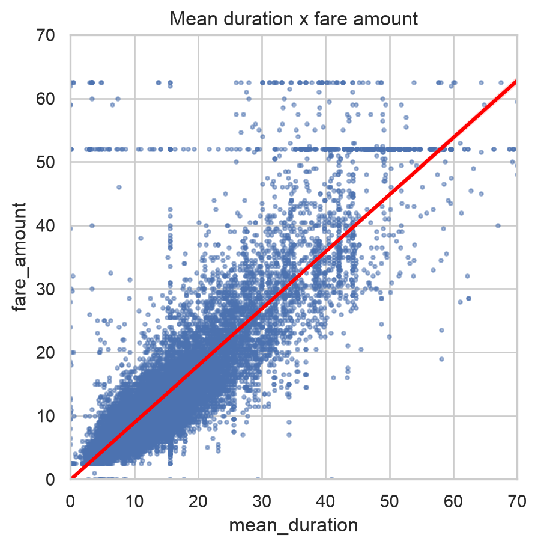

```python
# Create a scatter plot of duration and trip_distance, with a line of best fit
sns.set(style='whitegrid')
f = plt.figure()
f.set_figwidth(5)
f.set_figheight(5)
sns.regplot(x=df['mean_duration'], y=df['fare_amount'],
            scatter_kws={'alpha':0.5, 's':5},
            line_kws={'color':'red'})
plt.ylim(0, 70)
plt.xlim(0, 70)
plt.title('Mean duration x fare amount')
plt.show()
```

The mean_duration variable correlates with the target variable. But what are the horizontal lines around fare amounts of 52 dollars and 63 dollars? What are the values and how many are there?

We know what one of the lines represents. 62 dollars and 50 cents is the maximum that was imputed for outliers, so all former outliers will now have fare amounts of $62.50. What is the other line?

Check the value of the rides in the second horizontal line in the scatter plot.

```python
df[df['fare_amount'] > 50]['fare_amount'].value_counts().head()
```

```
fare_amount
52.0    514
62.5     84
59.0      9
50.5      9
57.5      8
Name: count, dtype: int64
```

There are 514 trips whose fares were $52.

Examine the first 30 of these trips.

```python
# Set pandas to display all columns
pd.set_option('display.max_columns', None)
df[df['fare_amount']==52].head(30)
```

|  | Unnamed: 0 | VendorID | tpep_pickup_datetime | tpep_dropoff_datetime | passenger_count | trip_distance | RatecodeID | store_and_fwd_flag | PULocationID | DOLocationID | payment_type | fare_amount | extra | mta_tax | tip_amount | tolls_amount | improvement_surcharge | total_amount | duration | pickup_dropoff | mean_distance | mean_duration | day | month | rush_hour |
| --- | --- | --- | --- | --- | --- | --- | --- | --- | --- | --- | --- | --- | --- | --- | --- | --- | --- | --- | --- | --- | --- | --- | --- | --- | --- |
| 11 | 18600059 | 2 | 2017-03-05 19:15:30 | 2017-03-05 19:52:18 | 2 | 18.90 | 2 | N | 236 | 132 | 1 | 52.0 | 0.0 | 0.5 | 14.58 | 5.54 | 0.3 | 72.92 | 36.800000 | 236 132 | 19.211667 | 40.500000 | sunday | mar | 0 |
| 110 | 47959795 | 1 | 2017-06-03 14:24:57 | 2017-06-03 15:31:48 | 1 | 18.00 | 2 | N | 132 | 163 | 1 | 52.0 | 0.0 | 0.5 | 0.00 | 0.00 | 0.3 | 52.80 | 66.850000 | 132 163 | 19.229000 | 52.941667 | saturday | jun | 0 |
| 161 | 95729204 | 2 | 2017-11-11 20:16:16 | 2017-11-11 20:17:14 | 1 | 0.23 | 2 | N | 132 | 132 | 2 | 52.0 | 0.0 | 0.5 | 0.00 | 0.00 | 0.3 | 52.80 | 0.966667 | 132 132 | 2.255862 | 3.021839 | saturday | nov | 0 |
| 247 | 103404868 | 2 | 2017-12-06 23:37:08 | 2017-12-07 00:06:19 | 1 | 18.93 | 2 | N | 132 | 79 | 2 | 52.0 | 0.0 | 0.5 | 0.00 | 0.00 | 0.3 | 52.80 | 29.183333 | 132 79 | 19.431667 | 47.275000 | wednesday | dec | 23 |
| 379 | 80479432 | 2 | 2017-09-24 23:45:45 | 2017-09-25 00:15:14 | 1 | 17.99 | 2 | N | 132 | 234 | 1 | 52.0 | 0.0 | 0.5 | 14.64 | 5.76 | 0.3 | 73.20 | 29.483333 | 132 234 | 17.654000 | 49.833333 | sunday | sep | 0 |
| 388 | 16226157 | 1 | 2017-02-28 18:30:05 | 2017-02-28 19:09:55 | 1 | 18.40 | 2 | N | 132 | 48 | 2 | 52.0 | 4.5 | 0.5 | 0.00 | 5.54 | 0.3 | 62.84 | 39.833333 | 132 48 | 18.761905 | 58.246032 | tuesday | feb | 18 |
| 406 | 55253442 | 2 | 2017-06-05 12:51:58 | 2017-06-05 13:07:35 | 1 | 4.73 | 2 | N | 228 | 88 | 2 | 52.0 | 0.0 | 0.5 | 0.00 | 5.76 | 0.3 | 58.56 | 15.616667 | 228 88 | 4.730000 | 15.616667 | monday | jun | 12 |
| 449 | 65900029 | 2 | 2017-08-03 22:47:14 | 2017-08-03 23:32:41 | 2 | 18.21 | 2 | N | 132 | 48 | 2 | 52.0 | 0.0 | 0.5 | 0.00 | 5.76 | 0.3 | 58.56 | 45.450000 | 132 48 | 18.761905 | 58.246032 | thursday | aug | 22 |
| 468 | 80904240 | 2 | 2017-09-26 13:48:26 | 2017-09-26 14:31:17 | 1 | 17.27 | 2 | N | 186 | 132 | 2 | 52.0 | 0.0 | 0.5 | 0.00 | 5.76 | 0.3 | 58.56 | 42.850000 | 186 132 | 17.096000 | 42.920000 | tuesday | sep | 13 |
| 520 | 33706214 | 2 | 2017-04-23 21:34:48 | 2017-04-23 22:46:23 | 6 | 18.34 | 2 | N | 132 | 148 | 1 | 52.0 | 0.0 | 0.5 | 5.00 | 0.00 | 0.3 | 57.80 | 71.583333 | 132 148 | 17.994286 | 46.340476 | sunday | apr | 0 |
| 569 | 99259872 | 2 | 2017-11-22 21:31:32 | 2017-11-22 22:00:25 | 1 | 18.65 | 2 | N | 132 | 144 | 1 | 52.0 | 0.0 | 0.5 | 10.56 | 0.00 | 0.3 | 63.36 | 28.883333 | 132 144 | 18.537500 | 37.000000 | wednesday | nov | 21 |
| 572 | 61050418 | 2 | 2017-07-18 13:29:06 | 2017-07-18 13:29:19 | 1 | 0.00 | 2 | N | 230 | 161 | 1 | 52.0 | 0.0 | 0.5 | 11.71 | 5.76 | 0.3 | 70.27 | 0.216667 | 230 161 | 0.685484 | 7.965591 | tuesday | jul | 13 |
| 586 | 54444647 | 2 | 2017-06-26 13:39:12 | 2017-06-26 14:34:54 | 1 | 17.76 | 2 | N | 211 | 132 | 1 | 52.0 | 0.0 | 0.5 | 11.71 | 5.76 | 0.3 | 70.27 | 55.700000 | 211 132 | 16.580000 | 61.691667 | monday | jun | 13 |
| 692 | 94424289 | 2 | 2017-11-07 22:15:00 | 2017-11-07 22:45:32 | 2 | 16.97 | 2 | N | 132 | 170 | 1 | 52.0 | 0.0 | 0.5 | 11.71 | 5.76 | 0.3 | 70.27 | 30.533333 | 132 170 | 17.203000 | 37.113333 | tuesday | nov | 22 |
| 717 | 103094220 | 1 | 2017-12-06 05:19:50 | 2017-12-06 05:53:52 | 1 | 20.80 | 2 | N | 132 | 239 | 1 | 52.0 | 0.0 | 0.5 | 5.85 | 5.76 | 0.3 | 64.41 | 34.033333 | 132 239 | 20.901250 | 44.862500 | wednesday | dec | 5 |
| 719 | 66115834 | 1 | 2017-08-04 17:53:34 | 2017-08-04 18:50:56 | 1 | 21.60 | 2 | N | 264 | 264 | 1 | 52.0 | 4.5 | 0.5 | 12.60 | 5.76 | 0.3 | 75.66 | 57.366667 | 264 264 | 3.191516 | 15.618773 | friday | aug | 17 |
| 782 | 55934137 | 2 | 2017-06-09 09:31:25 | 2017-06-09 10:24:10 | 2 | 18.81 | 2 | N | 163 | 132 | 1 | 52.0 | 0.0 | 0.5 | 13.20 | 0.00 | 0.3 | 66.00 | 52.750000 | 163 132 | 17.275833 | 52.338889 | friday | jun | 9 |
| 816 | 13731926 | 2 | 2017-02-21 06:11:03 | 2017-02-21 06:59:39 | 5 | 16.94 | 2 | N | 132 | 170 | 1 | 52.0 | 0.0 | 0.5 | 2.00 | 5.54 | 0.3 | 60.34 | 48.600000 | 132 170 | 17.203000 | 37.113333 | tuesday | feb | 6 |
| 818 | 52277743 | 2 | 2017-06-20 08:15:18 | 2017-06-20 10:24:37 | 1 | 17.77 | 2 | N | 132 | 246 | 1 | 52.0 | 0.0 | 0.5 | 11.71 | 5.76 | 0.3 | 70.27 | 88.783333 | 132 246 | 18.515000 | 66.316667 | tuesday | jun | 8 |
| 835 | 2684305 | 2 | 2017-01-10 22:29:47 | 2017-01-10 23:06:46 | 1 | 18.57 | 2 | N | 132 | 48 | 1 | 52.0 | 0.0 | 0.5 | 13.20 | 0.00 | 0.3 | 66.00 | 36.983333 | 132 48 | 18.761905 | 58.246032 | tuesday | jan | 22 |
| 840 | 90860814 | 2 | 2017-10-27 21:50:00 | 2017-10-27 22:35:04 | 1 | 22.43 | 2 | N | 132 | 163 | 2 | 52.0 | 0.0 | 0.5 | 0.00 | 5.76 | 0.3 | 58.56 | 45.066667 | 132 163 | 19.229000 | 52.941667 | friday | oct | 21 |
| 861 | 106575186 | 1 | 2017-12-16 06:39:59 | 2017-12-16 07:07:59 | 2 | 17.80 | 2 | N | 75 | 132 | 1 | 52.0 | 0.0 | 0.5 | 6.00 | 5.76 | 0.3 | 64.56 | 28.000000 | 75 132 | 18.442500 | 36.204167 | saturday | dec | 0 |
| 881 | 110495611 | 2 | 2017-12-30 05:25:29 | 2017-12-30 06:01:29 | 6 | 18.23 | 2 | N | 68 | 132 | 2 | 52.0 | 0.0 | 0.5 | 0.00 | 0.00 | 0.3 | 52.80 | 36.000000 | 68 132 | 18.785000 | 58.041667 | saturday | dec | 0 |
| 958 | 87017503 | 1 | 2017-10-15 22:39:12 | 2017-10-15 23:14:22 | 1 | 21.80 | 2 | N | 132 | 261 | 2 | 52.0 | 0.0 | 0.5 | 0.00 | 0.00 | 0.3 | 52.80 | 35.166667 | 132 261 | 22.115000 | 51.493750 | sunday | oct | 0 |
| 970 | 12762608 | 2 | 2017-02-17 20:39:42 | 2017-02-17 21:13:29 | 1 | 19.57 | 2 | N | 132 | 140 | 1 | 52.0 | 0.0 | 0.5 | 11.67 | 5.54 | 0.3 | 70.01 | 33.783333 | 132 140 | 19.293333 | 36.791667 | friday | feb | 20 |
| 984 | 71264442 | 1 | 2017-08-23 18:23:26 | 2017-08-23 19:18:29 | 1 | 16.70 | 2 | N | 132 | 230 | 1 | 52.0 | 4.5 | 0.5 | 42.29 | 0.00 | 0.3 | 99.59 | 55.050000 | 132 230 | 18.571200 | 59.598000 | wednesday | aug | 18 |
| 1082 | 11006300 | 2 | 2017-02-07 17:20:19 | 2017-02-07 17:34:41 | 1 | 1.09 | 2 | N | 170 | 48 | 2 | 52.0 | 4.5 | 0.5 | 0.00 | 5.54 | 0.3 | 62.84 | 14.366667 | 170 48 | 1.265789 | 14.135965 | tuesday | feb | 17 |
| 1097 | 68882036 | 2 | 2017-08-14 23:01:15 | 2017-08-14 23:03:35 | 5 | 2.12 | 2 | N | 265 | 265 | 2 | 52.0 | 0.0 | 0.5 | 0.00 | 0.00 | 0.3 | 52.80 | 2.333333 | 265 265 | 0.753077 | 3.411538 | monday | aug | 23 |
| 1110 | 74720333 | 1 | 2017-09-06 10:46:17 | 2017-09-06 11:44:41 | 1 | 19.10 | 2 | N | 239 | 132 | 1 | 52.0 | 0.0 | 0.5 | 15.80 | 0.00 | 0.3 | 68.60 | 58.400000 | 239 132 | 19.795000 | 50.562500 | wednesday | sep | 10 |
| 1179 | 51937907 | 2 | 2017-06-19 06:23:13 | 2017-06-19 07:03:53 | 6 | 19.77 | 2 | N | 238 | 132 | 1 | 52.0 | 0.0 | 0.5 | 17.57 | 5.76 | 0.3 | 76.13 | 40.666667 | 238 132 | 19.470000 | 53.861111 | monday | jun | 6 |

It seems that almost all of the trips in the first 30 rows where the fare amount was $52 either begin or end at location 132, and all of them have a RatecodeID of 2.

There is no readily apparent reason why PULocation 132 should have so many fares of 52 dollars. They seem to occur on all different days, at different times, with both vendors, in all months. However, there are many toll amounts of $5.76 and $5.54. This would seem to indicate that location 132 is in an area that frequently requires tolls to get to and from. It’s likely this is an airport.

The data dictionary says that RatecodeID of 2 indicates trips for JFK, which is John F. Kennedy International Airport. A quick Google search for “new york city taxi flat rate $52” indicates that in 2017 (the year that this data was collected) there was indeed a flat fare for taxi trips between JFK airport (in Queens) and Manhattan.

Because RatecodeID is known from the data dictionary, the values for this rate code can be imputed back into the data after the model makes its predictions. This way you know that those data points will always be correct.

```python
df.info()
```

```
<class 'pandas.DataFrame'>
RangeIndex: 22699 entries, 0 to 22698
Data columns (total 25 columns):
 #   Column                 Non-Null Count  Dtype
---  ------                 --------------  -----
 0   Unnamed: 0             22699 non-null  int64
 1   VendorID               22699 non-null  int64
 2   tpep_pickup_datetime   22699 non-null  datetime64[us]
 3   tpep_dropoff_datetime  22699 non-null  datetime64[us]
 4   passenger_count        22699 non-null  int64
 5   trip_distance          22699 non-null  float64
 6   RatecodeID             22699 non-null  int64
 7   store_and_fwd_flag     22699 non-null  str
 8   PULocationID           22699 non-null  int64
 9   DOLocationID           22699 non-null  int64
```

[output cut: 17 more lines]

```python
df2 = df.copy()

df2 = df2.drop(['Unnamed: 0', 'tpep_dropoff_datetime', 'tpep_pickup_datetime',
               'trip_distance', 'RatecodeID', 'store_and_fwd_flag', 'PULocationID', 'DOLocationID',
               'payment_type', 'extra', 'mta_tax', 'tip_amount', 'tolls_amount', 'improvement_surcharge',
               'total_amount', 'tpep_dropoff_datetime', 'tpep_pickup_datetime', 'duration',
               'pickup_dropoff', 'day', 'month'
               ], axis=1)

df2.info()
```

```
<class 'pandas.DataFrame'>
RangeIndex: 22699 entries, 0 to 22698
Data columns (total 6 columns):
 #   Column           Non-Null Count  Dtype
---  ------           --------------  -----
 0   VendorID         22699 non-null  int64
 1   passenger_count  22699 non-null  int64
 2   fare_amount      22699 non-null  float64
 3   mean_distance    22699 non-null  float64
 4   mean_duration    22699 non-null  float64
 5   rush_hour        22699 non-null  int32
dtypes: float64(3), int32(1), int64(2)
memory usage: 975.5 KB
```

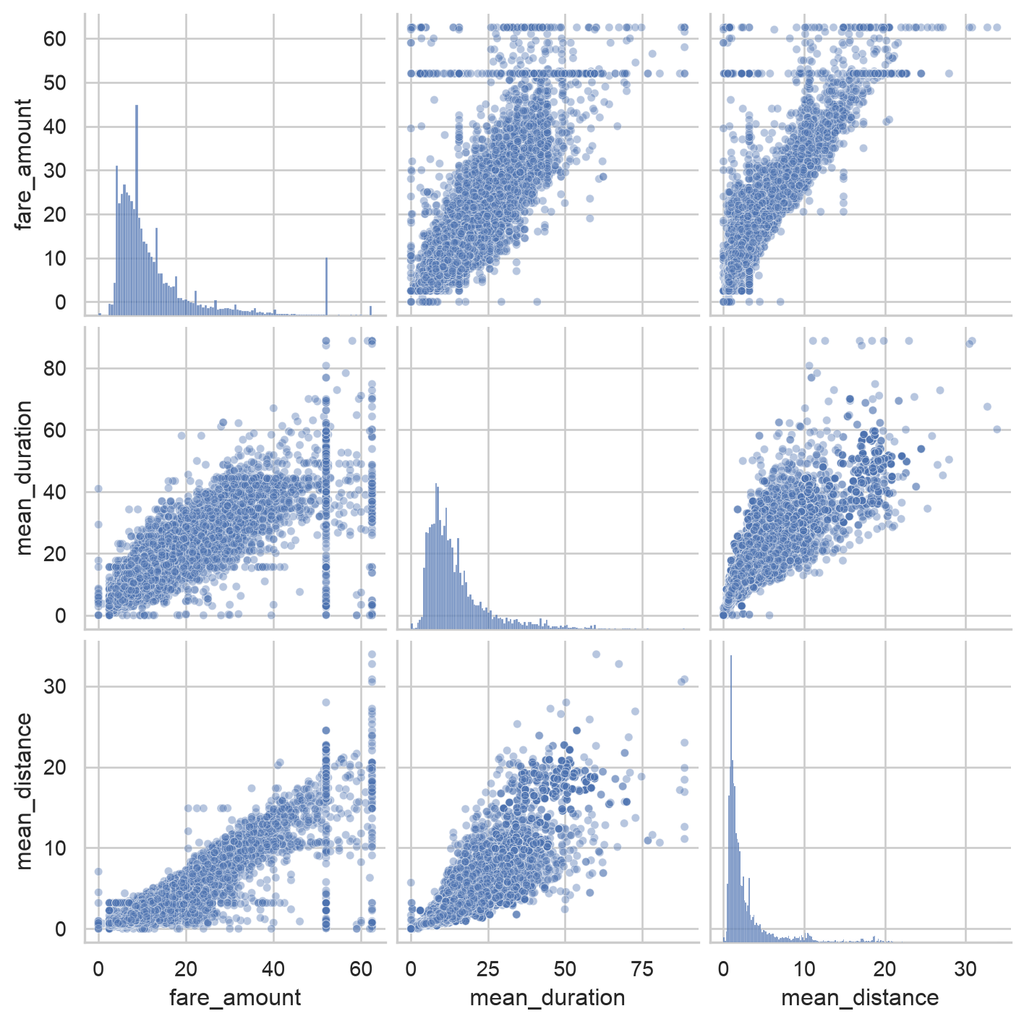

```python
# Create a pairplot to visualize pairwise relationships between variables in the data
### YOUR CODE HERE ###

sns.pairplot(df2[['fare_amount', 'mean_duration', 'mean_distance']],
             plot_kws={'alpha':0.4, 'size':5},
             );
```

```python
# Create correlation matrix containing pairwise correlation of columns, using pearson correlation coefficient
df2.corr(method='pearson')
```

|  | VendorID | passenger_count | fare_amount | mean_distance | mean_duration | rush_hour |
| --- | --- | --- | --- | --- | --- | --- |
| VendorID | 1.000000 | 0.266463 | 0.001045 | 0.004741 | 0.001876 | 0.003815 |
| passenger_count | 0.266463 | 1.000000 | 0.014942 | 0.013428 | 0.015852 | -0.010907 |
| fare_amount | 0.001045 | 0.014942 | 1.000000 | 0.910185 | 0.859105 | 0.009739 |
| mean_distance | 0.004741 | 0.013428 | 0.910185 | 1.000000 | 0.874864 | -0.010751 |
| mean_duration | 0.001876 | 0.015852 | 0.859105 | 0.874864 | 1.000000 | 0.015471 |
| rush_hour | 0.003815 | -0.010907 | 0.009739 | -0.010751 | 0.015471 | 1.000000 |

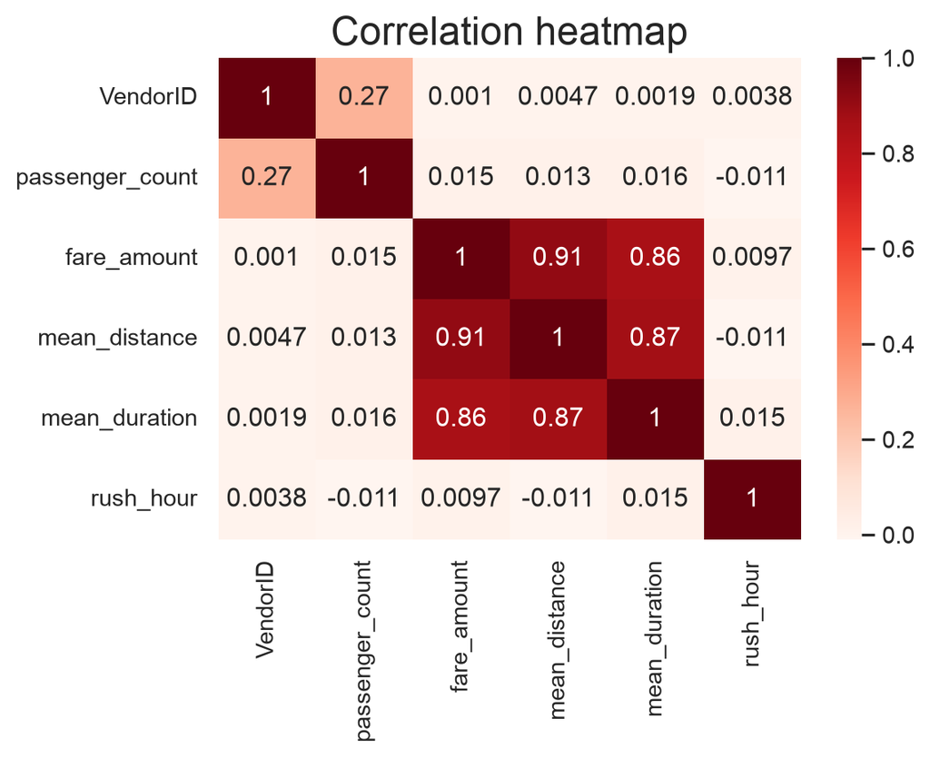

```python
# Create correlation heatmap

plt.figure(figsize=(6,4))
sns.heatmap(df2.corr(method='pearson'), annot=True, cmap='Reds')
plt.title('Correlation heatmap',
          fontsize=18)
plt.show()
```

mean_duration and mean_distance are both highly correlated with the target variable. They’re also both correlated with each other, with a Pearson correlation of 0.87.

Recall that highly correlated predictor variables can be bad for linear regression models when you want to be able to draw statistical inferences about the data from the model. However, correlated predictor variables can still be used to create an accurate predictor if the prediction itself is more important than using the model as a tool to learn about your data.

This model will predict fare_amount, which will be used as a predictor variable in machine learning models. Therefore, try modeling with both variables even though they are correlated.

Split data into outcome variable and features

```python
df2.info()
```

```
<class 'pandas.DataFrame'>
RangeIndex: 22699 entries, 0 to 22698
Data columns (total 6 columns):
 #   Column           Non-Null Count  Dtype
---  ------           --------------  -----
 0   VendorID         22699 non-null  int64
 1   passenger_count  22699 non-null  int64
 2   fare_amount      22699 non-null  float64
 3   mean_distance    22699 non-null  float64
 4   mean_duration    22699 non-null  float64
 5   rush_hour        22699 non-null  int32
dtypes: float64(3), int32(1), int64(2)
memory usage: 975.5 KB
```

Set X and y variables. X represents the features and y represents the outcome (target) variable.

```python
# Remove the target column from the features
X = df2.drop(columns=['fare_amount'])

# Set y variable
y = df2[['fare_amount']]

# Display first few rows
X.head()
```

|  | VendorID | passenger_count | mean_distance | mean_duration | rush_hour |
| --- | --- | --- | --- | --- | --- |
| 0 | 2 | 6 | 3.521667 | 22.847222 | 0 |
| 1 | 1 | 1 | 3.108889 | 24.470370 | 14 |
| 2 | 1 | 1 | 0.881429 | 7.250000 | 7 |
| 3 | 2 | 1 | 3.700000 | 30.250000 | 0 |
| 4 | 2 | 1 | 4.435000 | 14.616667 | 0 |

### 2.3.4 Pre-process data

#### 2.3.4.1 Dummy encode categorical variables

```python
# Convert VendorID to string
X['VendorID'] = X['VendorID'].astype(str)

# Get dummies
X = pd.get_dummies(X, drop_first=True)
X.head()
```

|  | passenger_count | mean_distance | mean_duration | rush_hour | VendorID_2 |
| --- | --- | --- | --- | --- | --- |
| 0 | 6 | 3.521667 | 22.847222 | 0 | True |
| 1 | 1 | 3.108889 | 24.470370 | 14 | False |
| 2 | 1 | 0.881429 | 7.250000 | 7 | False |
| 3 | 1 | 3.700000 | 30.250000 | 0 | True |
| 4 | 1 | 4.435000 | 14.616667 | 0 | True |

#### 2.3.4.2 Split data into training and test sets

```python
# Create training and testing sets

X_train, X_test, y_train, y_test = train_test_split(X, y, test_size=0.2, random_state=0)
```

```python
# Standardize the X variables
scaler = StandardScaler().fit(X_train)
X_train_scaled = scaler.transform(X_train)
print('X_train scaled:', X_train_scaled)
```

```
X_train scaled: [[-0.50301524  0.8694684   0.17616665 -1.25181457  0.89286563]
 [-0.50301524 -0.60011281 -0.69829589 -0.50950243  0.89286563]
 [ 0.27331093 -0.47829156 -0.57301906 -1.25181457 -1.11998936]
 ...
 [-0.50301524 -0.45121122 -0.6788917   0.60396577 -1.11998936]
 [-0.50301524 -0.58944763 -0.85743597  0.97512183 -1.11998936]
 [ 1.82596329  0.83673851  1.13212101  0.48024708  0.89286563]]
```

### 2.3.5 Fit multiple linear regression model

Instantiate model and fit it to the training data

```python
# Fit model to the training data
lr=LinearRegression()
lr.fit(X_train_scaled, y_train)
```

```
LinearRegression()
```

### 2.3.6 Evaluate model

#### 2.3.6.1 Train data

Evaluate your model performance by calculating the residual sum of squares and the explained variance score (R^2). Calculate the Mean Absolute Error, Mean Squared Error, and the Root Mean Squared Error.

```python
# Evaluate the model performance on the training data
r_sq = lr.score(X_train_scaled, y_train)
print('Coefficient of determination:', r_sq)
y_pred_train = lr.predict(X_train_scaled)
print('R^2:', r2_score(y_train, y_pred_train))
print('MAE:', mean_absolute_error(y_train, y_pred_train))
print('MSE:', mean_squared_error(y_train, y_pred_train))
print('RMSE:',np.sqrt(mean_squared_error(y_train, y_pred_train)))
```

```
Coefficient of determination: 0.8399005858935237
R^2: 0.8399005858935237
MAE: 2.1858313447293454
MSE: 17.883351745932664
RMSE: 4.228871214157824
```

#### 2.3.6.2 Test data

Evaluate your model performance by calculating the residual sum of squares and the explained variance score (R^2). Calculate the Mean Absolute Error, Mean Squared Error, and the Root Mean Squared Error.

Calculate the same metrics on the test data. Remember to scale the X_test data using the scaler that was fit to the training data. Do not refit the scaler to the testing data, just transform it. Call the results X_test_scaled.

```python
# Scale the X_test data
X_test_scaled = scaler.transform(X_test)
```

```python
# Evaluate the model performance on the testing data
r_sq_test = lr.score(X_test_scaled, y_test)
print('Coefficient of determination:', r_sq_test)
y_pred_test = lr.predict(X_test_scaled)
print('R^2:', r2_score(y_test, y_pred_test))
print('MAE:', mean_absolute_error(y_test,y_pred_test))
print('MSE:', mean_squared_error(y_test, y_pred_test))
print('RMSE:',np.sqrt(mean_squared_error(y_test, y_pred_test)))
```

```
Coefficient of determination: 0.8680858771386532
R^2: 0.8680858771386532
MAE: 2.1381788902629526
MSE: 14.345211535170465
RMSE: 3.787507298365307
```

The model performs similarly on both the training and testing data, indicating that it generalizes well to unseen data. The R^2 values suggest that the model explains a significant portion of the variance in fare amounts, while the MAE and RMSE values provide insights into the average prediction error.

### 2.3.7 Results

```python
# Create a `results` dataframe
results = pd.DataFrame(data={'actual': y_test['fare_amount'],
                             'predicted': y_pred_test.ravel()})
results['residual'] = results['actual'] - results['predicted']
results.head()
```

|  | actual | predicted | residual |
| --- | --- | --- | --- |
| 5818 | 14.0 | 12.258303 | 1.741697 |
| 18134 | 28.0 | 16.377527 | 11.622473 |
| 4655 | 5.5 | 6.815503 | -1.315503 |
| 7378 | 15.5 | 16.196890 | -0.696890 |
| 13914 | 9.5 | 10.674366 | -1.174366 |

### 2.3.8 Visualize model results

Create a scatterplot to visualize actual vs. predicted.

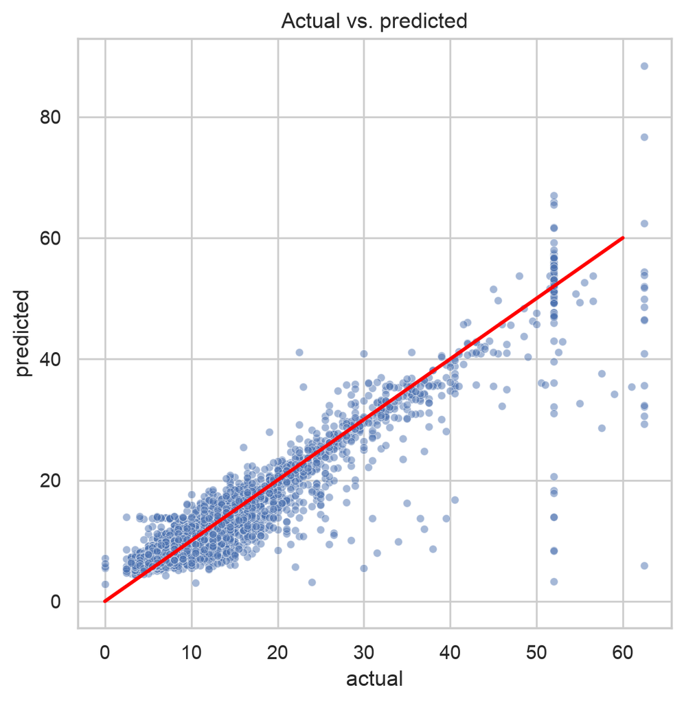

```python
# Create a scatterplot to visualize `predicted` over `actual`
fig, ax = plt.subplots(figsize=(6, 6))
sns.set(style='whitegrid')
sns.scatterplot(x='actual',
                y='predicted',
                data=results,
                s=20,
                alpha=0.5,
                ax=ax
)
# Draw an x=y line to show what the results would be if the model were perfect
plt.plot([0,60], [0,60], c='red', linewidth=2)
plt.title('Actual vs. predicted');
```

The scatterplot of actual vs. predicted fare amounts shows a positive correlation, indicating that the model is able to predict fare amounts reasonably well. The points are clustered around the x=y line, which represents perfect predictions. However, there is some spread around this line, suggesting that there are still some prediction errors.

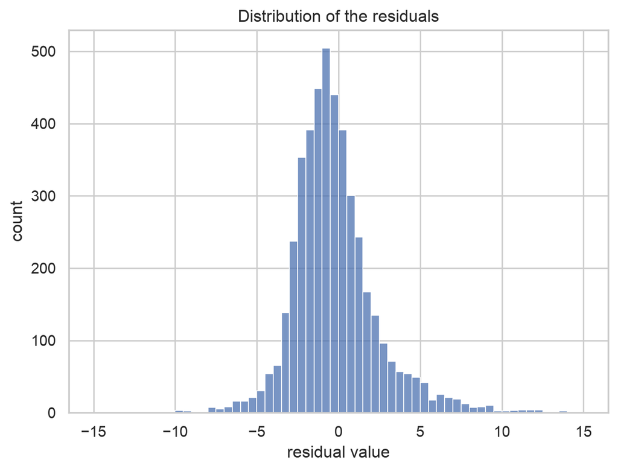

```python
# Visualize the distribution of the `residuals`
sns.histplot(results['residual'], bins=np.arange(-15,15.5,0.5))
plt.title('Distribution of the residuals')
plt.xlabel('residual value')
plt.ylabel('count');
```

The histogram of residuals shows that the prediction errors are approximately normally distributed, with most residuals falling within the range of -5 to 5. This indicates that the model’s predictions are generally accurate, with a few instances of larger errors. The distribution of residuals is centered around zero, which is a desirable property for a regression model, suggesting that there is no systematic bias in the predictions.

```python
results['residual'].mean()
```

```
np.float64(-0.015470572802781534)
```

The distribution of the residuals is approximately normal and has a mean of -0.015. The residuals represent the variance in the outcome variable that is not explained by the model. A normal distribution around zero is good, as it demonstrates that the model’s errors are evenly distributed and unbiased.

This multiple linear regression model provides a solid foundation for predicting taxi fare amounts based on various features. The model’s performance metrics indicate that it is effective at capturing the relationships in the data, and the visualizations of actual vs. predicted values and residuals further support its validity.

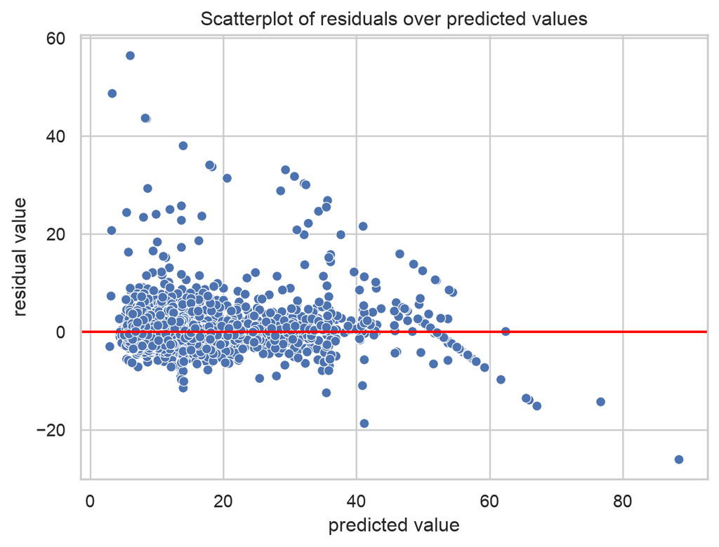

```python
# Create a scatterplot of `residuals` over `predicted`

sns.scatterplot(x='predicted', y='residual', data=results)
plt.axhline(0, c='red')
plt.title('Scatterplot of residuals over predicted values')
plt.xlabel('predicted value')
plt.ylabel('residual value')
plt.show()
```

### 2.3.9 Coefficients

```python
# Get model coefficients
coefficients = pd.DataFrame(lr.coef_, columns=X.columns)
coefficients
```

|  | passenger_count | mean_distance | mean_duration | rush_hour | VendorID_2 |
| --- | --- | --- | --- | --- | --- |
| 0 | 0.029315 | 7.138384 | 2.803413 | 0.13621 | -0.055374 |

The coefficients reveal that mean_distance was the feature with the greatest weight in the model’s final prediction. Be careful here! A common misinterpretation is that for every mile traveled, the fare amount increases by a mean of $7.13. This is incorrect. Remember, the data used to train the model was standardized with StandardScaler(). As such, the units are no longer miles. In other words, you cannot say “for every mile traveled…”, as stated above. The correct interpretation of this coefficient is: controlling for other variables, for every +1 change in standard deviation, the fare amount increases by a mean of $7.13.

Note also that because some highly correlated features were not removed, the confidence interval of this assessment is wider.

So, translate this back to miles instead of standard deviation (i.e., unscale the data for the final model).

Calculate the standard deviation of mean_distance in the X_train data.

```python
# 1. Calculate SD of `mean_distance` in X_train data
print(X_train['mean_distance'].std())

# 2. Divide the model coefficient by the standard deviation
print(7.133867 / X_train['mean_distance'].std())
```

```
3.5748129752564366
1.9955916713344304
```

### 2.3.10 Conclusion of the multiple regression model

These findings suggest that the model is effective for predicting taxi fare amounts based on the selected features. Future work could involve refining the model by exploring additional features, addressing multicollinearity among predictors, and validating the model on different datasets to ensure its robustness and generalizability.

More work must be done to prepare the predictions to be used as inputs into the model for the upcoming course. This work will be broken into the following steps:

Get the model’s predictions on the full dataset.

Impute the constant fare rate of $52 for all trips with rate codes of 2.

Check the model’s performance on the full dataset.

Save the final predictions and mean_duration and mean_distance columns for downstream use.

### 2.3.11 Extensions of the multiple regression model

2. Impute ratecode 2 fare

The data dictionary says that the RatecodeID column captures the following information:

1 = standard rate

2 = JFK (airport)

3 = Newark (airport)

4 = Nassau or Westchester

5 = Negotiated fare

6 = Group ride

This means that some fares don’t need to be predicted. They can simply be imputed based on their rate code. Specifically, all rate codes of 2 can be imputed with $52, as this is a flat rate for JFK airport.

The other rate codes have some variation (not shown here, but feel free to check for yourself). They are not a fixed rate, so these fares will remain untouched.

Impute 52 at all predictions where RatecodeID is 2.

```python
# Create predictions for the full dataset using the same preprocessing as training,
# then build final_preds and impute the flat fare for RatecodeID == 2.

# 1. Prepare full feature matrix from df2 (df2 was the cleaned copy used to build X)
X_full = df2.drop(columns=['fare_amount']).copy()

# 2. Ensure VendorID has same dtype as during training
X_full['VendorID'] = X_full['VendorID'].astype(str)

# 3. One-hot encode categorical variables to match training
X_full = pd.get_dummies(X_full, drop_first=True)

# 4. Reindex columns to exactly match training features (X) - fill missing columns with 0
X_full = X_full.reindex(columns=X.columns, fill_value=0)

# 5. Scale using the scaler fitted on the training data and predict with the trained model
X_full_scaled = scaler.transform(X_full)
y_preds_full = lr.predict(X_full_scaled).ravel()

# 6. Create a new df containing just the RatecodeID col from the whole dataset
final_preds = df[['RatecodeID']].copy()

# 7. Add a column containing all the predictions
final_preds['y_preds_full'] = y_preds_full

# 8. Impute a prediction of 52 at all rows where RatecodeID == 2
final_preds.loc[final_preds['RatecodeID']==2, 'y_preds_full'] = 52

# Check that it worked
final_preds[final_preds['RatecodeID']==2].head()
```

|  | RatecodeID | y_preds_full |
| --- | --- | --- |
| 11 | 2 | 52.0 |
| 110 | 2 | 52.0 |
| 161 | 2 | 52.0 |
| 247 | 2 | 52.0 |
| 379 | 2 | 52.0 |

3. Check performance on full dataset

```python
final_preds = final_preds['y_preds_full']
print('R^2:', r2_score(y, final_preds))
print('MAE:', mean_absolute_error(y, final_preds))
print('MSE:', mean_squared_error(y, final_preds))
print('RMSE:',np.sqrt(mean_squared_error(y, final_preds)))
```

```
R^2: 0.8910521346799533
MAE: 1.9929842302680052
MSE: 12.105271400176921
RMSE: 3.4792630541792784
```

The model’s performance on the full dataset, after imputing the flat fare for RatecodeID 2, shows a strong R^2 value and reasonable error metrics. This indicates that the model is effective at predicting taxi fare amounts across the entire dataset, including those with special rate codes.

4. Save final predictions and features for downstream use

```python
# Combine means columns with predictions column
nyc_preds_means = df[['mean_duration', 'mean_distance']].copy()
nyc_preds_means['predicted_fare'] = final_preds

nyc_preds_means.head()
```

|  | mean_duration | mean_distance | predicted_fare |
| --- | --- | --- | --- |
| 0 | 22.847222 | 3.521667 | 16.322800 |
| 1 | 24.470370 | 3.108889 | 16.182650 |
| 2 | 7.250000 | 0.881429 | 6.836798 |
| 3 | 30.250000 | 3.700000 | 18.619912 |
| 4 | 14.616667 | 4.435000 | 15.748302 |

This notebook was designed for teaching purposes. As such, there are some things to note that differ from best practice or from how tasks are typically performed.

When the mean_distance and mean_duration columns were computed, the means were calculated from the entire dataset. These same columns were then used to train a model that was used to predict on a test set. A test set is supposed to represent entirely new data that the model has not seen before, but in this case, some of its predictor variables were derived using data that was in the test set. This is known as data leakage. Data leakage is when information from your training data contaminates the test data. If your model has unexpectedly high scores, there is a good chance that there was some data leakage. To avoid data leakage in this modeling process, it would be best to compute the means using only the training set and then copy those into the test set, thus preventing values from the test set from being included in the computation of the means. This would have created some problems because it’s very likely that some combinations of pickup-dropoff locations would only appear in the test data (not the train data). This means that there would be NaNs in the test data, and further steps would be required to address this. In this case, the data leakage improved the R2 score by ~0.03.

Imputing the fare amount for RatecodeID 2 after training the model and then calculating model performance metrics on the post-imputed data is not best practice. It would be better to separate the rides that did not have rate codes of 2, train the model on that data specifically, and then add the RatecodeID 2 data (and its imputed rates) after. This would prevent training the model on data that you don’t need a model for, and would likely result in a better final model. However, the steps were combined for simplicity.

Models that predict values to be used in another downstream model are common in data science workflows. When models are deployed, the data cleaning, imputations, splits, predictions, etc. are done using modeling pipelines. Pandas was used here to granularize and explain the concepts of certain steps, but this process would be streamlined by machine learning engineers. The ideas are the same, but the implementation would differ. Once a modeling workflow has been validated, the entire process can be automated, often with no need for pandas and no need to examine outputs at each step. This entire process would be reduced to a page of code.

### 2.3.12 2.2.6 Build a machine learning model

The purpose of this model is to find ways to generate more revenue for taxi cab drivers.

The goal of this model is to predict whether or not a customer is a generous tipper.

*This activity has three parts:*

**Part 1: Ethical considerations**

Consider the ethical implications of the request

Should the objective of the model be adjusted?

**Part 2: Feature engineering**

Perform feature selection, extraction, and transformation to prepare the data for modeling

**Part 3: Modeling**

Build the models, evaluate them, and advise on next steps

```python
import numpy as np
import pandas as pd

import matplotlib.pyplot as plt

from sklearn.model_selection import GridSearchCV, train_test_split
from sklearn.metrics import roc_auc_score, roc_curve
from sklearn.metrics import accuracy_score, precision_score, recall_score,\
f1_score, confusion_matrix, ConfusionMatrixDisplay, RocCurveDisplay

from sklearn.ensemble import RandomForestClassifier, GradientBoostingClassifier

# Try to import xgboost; fall back to sklearn's GradientBoostingClassifier if unavailable
try:
    from xgboost import XGBClassifier, plot_importance
    XGBOOST_AVAILABLE = True
except Exception:
    XGBOOST_AVAILABLE = False
    XGBClassifier = None
    plot_importance = None
```

```python
# RUN THIS CELL TO SEE ALL COLUMNS
# This lets us see all of the columns, preventing Juptyer from redacting them.
pd.set_option('display.max_columns', None)
```

```python
# Load data
df0="/Users/macbookpro/Training/COURSERA_Data_Analytics/COURSERA_Data_Analytics/Data/2017_Yellow_Taxi_Trip_Data.csv"
df0 = pd.read_csv(df0)
nyc_preds_means="/Users/macbookpro/Training/COURSERA_Data_Analytics/COURSERA_Data_Analytics/Data/nyc_preds_means.csv"
nyc_preds_means = pd.read_csv(nyc_preds_means)
```

```python
# Inspect the first few rows of df0
df0.head()
```

|  | Unnamed: 0 | VendorID | tpep_pickup_datetime | tpep_dropoff_datetime | passenger_count | trip_distance | RatecodeID | store_and_fwd_flag | PULocationID | DOLocationID | payment_type | fare_amount | extra | mta_tax | tip_amount | tolls_amount | improvement_surcharge | total_amount |
| --- | --- | --- | --- | --- | --- | --- | --- | --- | --- | --- | --- | --- | --- | --- | --- | --- | --- | --- |
| 0 | 24870114 | 2 | 03/25/2017 8:55:43 AM | 03/25/2017 9:09:47 AM | 6 | 3.34 | 1 | N | 100 | 231 | 1 | 13.0 | 0.0 | 0.5 | 2.76 | 0.0 | 0.3 | 16.56 |
| 1 | 35634249 | 1 | 04/11/2017 2:53:28 PM | 04/11/2017 3:19:58 PM | 1 | 1.80 | 1 | N | 186 | 43 | 1 | 16.0 | 0.0 | 0.5 | 4.00 | 0.0 | 0.3 | 20.80 |
| 2 | 106203690 | 1 | 12/15/2017 7:26:56 AM | 12/15/2017 7:34:08 AM | 1 | 1.00 | 1 | N | 262 | 236 | 1 | 6.5 | 0.0 | 0.5 | 1.45 | 0.0 | 0.3 | 8.75 |
| 3 | 38942136 | 2 | 05/07/2017 1:17:59 PM | 05/07/2017 1:48:14 PM | 1 | 3.70 | 1 | N | 188 | 97 | 1 | 20.5 | 0.0 | 0.5 | 6.39 | 0.0 | 0.3 | 27.69 |
| 4 | 30841670 | 2 | 04/15/2017 11:32:20 PM | 04/15/2017 11:49:03 PM | 1 | 4.37 | 1 | N | 4 | 112 | 2 | 16.5 | 0.5 | 0.5 | 0.00 | 0.0 | 0.3 | 17.80 |

```python
# Inspect the first few rows of `nyc_preds_means`
nyc_preds_means.head()
```

|  | mean_duration | mean_distance | predicted_fare |
| --- | --- | --- | --- |
| 0 | 22.847222 | 3.521667 | 16.434245 |
| 1 | 24.470370 | 3.108889 | 16.052218 |
| 2 | 7.250000 | 0.881429 | 7.053706 |
| 3 | 30.250000 | 3.700000 | 18.731650 |
| 4 | 14.616667 | 4.435000 | 15.845642 |

```python
# Merge datasets
df0 = df0.merge(nyc_preds_means,
                left_index=True,
                right_index=True)

df0.head()
```

|  | Unnamed: 0 | VendorID | tpep_pickup_datetime | tpep_dropoff_datetime | passenger_count | trip_distance | RatecodeID | store_and_fwd_flag | PULocationID | DOLocationID | payment_type | fare_amount | extra | mta_tax | tip_amount | tolls_amount | improvement_surcharge | total_amount | mean_duration | mean_distance | predicted_fare |
| --- | --- | --- | --- | --- | --- | --- | --- | --- | --- | --- | --- | --- | --- | --- | --- | --- | --- | --- | --- | --- | --- |
| 0 | 24870114 | 2 | 03/25/2017 8:55:43 AM | 03/25/2017 9:09:47 AM | 6 | 3.34 | 1 | N | 100 | 231 | 1 | 13.0 | 0.0 | 0.5 | 2.76 | 0.0 | 0.3 | 16.56 | 22.847222 | 3.521667 | 16.434245 |
| 1 | 35634249 | 1 | 04/11/2017 2:53:28 PM | 04/11/2017 3:19:58 PM | 1 | 1.80 | 1 | N | 186 | 43 | 1 | 16.0 | 0.0 | 0.5 | 4.00 | 0.0 | 0.3 | 20.80 | 24.470370 | 3.108889 | 16.052218 |
| 2 | 106203690 | 1 | 12/15/2017 7:26:56 AM | 12/15/2017 7:34:08 AM | 1 | 1.00 | 1 | N | 262 | 236 | 1 | 6.5 | 0.0 | 0.5 | 1.45 | 0.0 | 0.3 | 8.75 | 7.250000 | 0.881429 | 7.053706 |
| 3 | 38942136 | 2 | 05/07/2017 1:17:59 PM | 05/07/2017 1:48:14 PM | 1 | 3.70 | 1 | N | 188 | 97 | 1 | 20.5 | 0.0 | 0.5 | 6.39 | 0.0 | 0.3 | 27.69 | 30.250000 | 3.700000 | 18.731650 |
| 4 | 30841670 | 2 | 04/15/2017 11:32:20 PM | 04/15/2017 11:49:03 PM | 1 | 4.37 | 1 | N | 4 | 112 | 2 | 16.5 | 0.5 | 0.5 | 0.00 | 0.0 | 0.3 | 17.80 | 14.616667 | 4.435000 | 15.845642 |

```python
# Inspect the first few rows of `nyc_preds_means`
nyc_preds_means.head()
```

|  | mean_duration | mean_distance | predicted_fare |
| --- | --- | --- | --- |
| 0 | 22.847222 | 3.521667 | 16.434245 |
| 1 | 24.470370 | 3.108889 | 16.052218 |
| 2 | 7.250000 | 0.881429 | 7.053706 |
| 3 | 30.250000 | 3.700000 | 18.731650 |
| 4 | 14.616667 | 4.435000 | 15.845642 |

```python
# Merge datasets
df0 = df0.merge(nyc_preds_means,
                left_index=True,
                right_index=True)

df0.head()
```

|  | Unnamed: 0 | VendorID | tpep_pickup_datetime | tpep_dropoff_datetime | passenger_count | trip_distance | RatecodeID | store_and_fwd_flag | PULocationID | DOLocationID | payment_type | fare_amount | extra | mta_tax | tip_amount | tolls_amount | improvement_surcharge | total_amount | mean_duration_x | mean_distance_x | predicted_fare_x | mean_duration_y | mean_distance_y | predicted_fare_y |
| --- | --- | --- | --- | --- | --- | --- | --- | --- | --- | --- | --- | --- | --- | --- | --- | --- | --- | --- | --- | --- | --- | --- | --- | --- |
| 0 | 24870114 | 2 | 03/25/2017 8:55:43 AM | 03/25/2017 9:09:47 AM | 6 | 3.34 | 1 | N | 100 | 231 | 1 | 13.0 | 0.0 | 0.5 | 2.76 | 0.0 | 0.3 | 16.56 | 22.847222 | 3.521667 | 16.434245 | 22.847222 | 3.521667 | 16.434245 |
| 1 | 35634249 | 1 | 04/11/2017 2:53:28 PM | 04/11/2017 3:19:58 PM | 1 | 1.80 | 1 | N | 186 | 43 | 1 | 16.0 | 0.0 | 0.5 | 4.00 | 0.0 | 0.3 | 20.80 | 24.470370 | 3.108889 | 16.052218 | 24.470370 | 3.108889 | 16.052218 |
| 2 | 106203690 | 1 | 12/15/2017 7:26:56 AM | 12/15/2017 7:34:08 AM | 1 | 1.00 | 1 | N | 262 | 236 | 1 | 6.5 | 0.0 | 0.5 | 1.45 | 0.0 | 0.3 | 8.75 | 7.250000 | 0.881429 | 7.053706 | 7.250000 | 0.881429 | 7.053706 |
| 3 | 38942136 | 2 | 05/07/2017 1:17:59 PM | 05/07/2017 1:48:14 PM | 1 | 3.70 | 1 | N | 188 | 97 | 1 | 20.5 | 0.0 | 0.5 | 6.39 | 0.0 | 0.3 | 27.69 | 30.250000 | 3.700000 | 18.731650 | 30.250000 | 3.700000 | 18.731650 |
| 4 | 30841670 | 2 | 04/15/2017 11:32:20 PM | 04/15/2017 11:49:03 PM | 1 | 4.37 | 1 | N | 4 | 112 | 2 | 16.5 | 0.5 | 0.5 | 0.00 | 0.0 | 0.3 | 17.80 | 14.616667 | 4.435000 | 15.845642 | 14.616667 | 4.435000 | 15.845642 |

### 2.3.13 Feature engineering

```python
df0.info()
```

```
<class 'pandas.DataFrame'>
RangeIndex: 22699 entries, 0 to 22698
Data columns (total 24 columns):
 #   Column                 Non-Null Count  Dtype
---  ------                 --------------  -----
 0   Unnamed: 0             22699 non-null  int64
 1   VendorID               22699 non-null  int64
 2   tpep_pickup_datetime   22699 non-null  str
 3   tpep_dropoff_datetime  22699 non-null  str
 4   passenger_count        22699 non-null  int64
 5   trip_distance          22699 non-null  float64
 6   RatecodeID             22699 non-null  int64
 7   store_and_fwd_flag     22699 non-null  str
 8   PULocationID           22699 non-null  int64
 9   DOLocationID           22699 non-null  int64
```

[output cut: 16 more lines]

We krom your EDA that customers who pay cash generally have a tip amount of $0. To meet the modeling objective, you’ll need to sample the data to select only the customers who pay with credit card.

Copy df0 and assign the result to a variable called df1. Then, use a Boolean mask to filter df1 so it contains only customers who paid with credit card.

```python
# Subset the data to isolate only customers who paid by credit card
df1 = df0[df0['payment_type']==1]
```

**Target**

Notice that there isn’t a column that indicates tip percent, which is what you need to create the target variable. You’ll have to engineer it.

Add a tip_percent column to the dataframe by performing the following calculation:

Round the result to three places beyond the decimal. This is an important step. It affects how many customers are labeled as generous tipper. In fact, without performing this step, approximately 1,800 people who do tip ≥ 20% would be labeled as not generous.

To understand why, you must consider how floats work. Computers make their calculations using floating-point arithmetic (hence the word “float”). Floating-point arithmetic is a system that allows computers to express both very large numbers and very small numbers with a high degree of precision, encoded in binary. However, precision is limited by the number of bits used to represent a number, which is generally 32 or 64, depending on the capabilities of your operating system.

This comes with limitations in that sometimes calculations that should result in clean, precise values end up being encoded as very long decimals. Take, for example, the following calculation:

```python
# Run this cell
1.1 + 2.2
```

```
3.3000000000000003
```

Notice the three that is 16 places to the right of the decimal. As a consequence, if you were to then have a step in your code that identifies values ≤ 3.3, this would not be included in the result. Therefore, whenever you perform a calculation to compute a number that is then used to make an important decision or filtration, round the number. How many degrees of precision you round to is your decision, which should be based on your use case.

Refer to this [Link](https://floating-point-gui.de/formats/fp/) for more information about floating-point arithmetic.

```python
# Create tip % col
df1['tip_percent'] = round(df1['tip_amount'] / (df1['total_amount'] - df1['tip_amount']), 3)
```

Now create another column called generous. This will be the target variable. The column should be a binary indicator of whether or not a customer tipped ≥ 20% (0=no, 1=yes).

Begin with making the generous column a copy of the tip_percent column. Reassign the column by converting it to Boolean (True/False). Reassign the column by converting Boolean to binary (1/0).

```python
# Create 'generous' col (target)
df1['generous'] = df1['tip_percent']
df1['generous'] = (df1['generous'] >= 0.2)
df1['generous'] = df1['generous'].astype(int)
```

**Create day column**

Next, we’re going to be working with the pickup and dropoff columns.

Convert the tpep_pickup_datetime and tpep_dropoff_datetime columns to datetime.

```python
# Convert pickup and dropoff cols to datetime
df1['tpep_pickup_datetime'] = pd.to_datetime(df1['tpep_pickup_datetime'], format='%m/%d/%Y %I:%M:%S %p')
df1['tpep_dropoff_datetime'] = pd.to_datetime(df1['tpep_dropoff_datetime'], format='%m/%d/%Y %I:%M:%S %p')
```

Create a day column that contains only the day of the week when each passenger was picked up. Then, convert the values to lowercase.

```python
# Create a 'day' col
df1['day'] = df1['tpep_pickup_datetime'].dt.day_name().str.lower()
```

**Create time of day columns**

Next, engineer four new columns that represent time of day bins. Each column should contain binary values (0=no, 1=yes) that indicate whether a trip began (picked up) during the following times:

am_rush = [06:00–10:00)

daytime = [10:00–16:00)

pm_rush = [16:00–20:00)

nighttime = [20:00–06:00)

To do this, first create the four columns. For now, each new column should be identical and contain the same information: the hour (only) from the tpep_pickup_datetime column.

```python
# Create 'am_rush' col
df1['am_rush'] = df1['tpep_pickup_datetime'].dt.hour

# Create 'daytime' col
df1['daytime'] = df1['tpep_pickup_datetime'].dt.hour

# Create 'pm_rush' col
df1['pm_rush'] = df1['tpep_pickup_datetime'].dt.hour

# Create 'nighttime' col
df1['nighttime'] = df1['tpep_pickup_datetime'].dt.hour
```

We’ll need to write four functions to convert each new column to binary (0/1). Begin with am_rush. Complete the function so if the hour is between [06:00–10:00), it returns 1, otherwise, it returns 0.

```python
# Define 'am_rush()' conversion function [06:00–10:00)
def am_rush(hour):
    if 6 <= hour['am_rush'] < 10:
        val = 1
    else:
        val = 0
    return val
```

Now, apply the am_rush() function to the am_rush series to perform the conversion. Print the first five values of the column to make sure it did what you expected it to do.

Note: Be careful! If you run this cell twice, the function will be reapplied and the values will all be changed to 0.

```python
# Apply 'am_rush' function to the 'am_rush' series
df1['am_rush'] = df1.apply(am_rush, axis=1)
df1['am_rush'].head()
```

```
0    1
1    0
2    1
3    0
5    0
Name: am_rush, dtype: int64
```

Write functions to convert the three remaining columns and apply them to their respective series.

```python
# Define 'daytime()' conversion function [10:00–16:00)
def daytime(hour):
    if 10 <= hour['daytime'] < 16:
        val = 1
    else:
        val = 0
    return val
```

```python
# Apply 'daytime' function to the 'daytime' series
df1['daytime'] = df1.apply(daytime, axis=1)
```

```python
# Define 'pm_rush()' conversion function [16:00–20:00)
def pm_rush(hour):
    if 16 <= hour['pm_rush'] < 20:
        val = 1
    else:
        val = 0
    return val
```

```python
# Apply 'pm_rush' function to the 'pm_rush' series
df1['pm_rush'] = df1.apply(pm_rush, axis=1)
```

```python
# Define 'nighttime()' conversion function [20:00–06:00)
def nighttime(hour):
    if 20 <= hour['nighttime'] < 24:
        val = 1
    elif 0 <= hour['nighttime'] < 6:
        val = 1
    else:
        val = 0
    return val
```

```python
# Apply 'nighttime' function to the 'nighttime' series
df1['nighttime'] = df1.apply(nighttime, axis=1)
```

**Create month column** Now, create a month column that contains only the abbreviated name of the month when each passenger was picked up, then convert the result to lowercase.

```python
# Create 'month' col
df1['month'] = df1['tpep_pickup_datetime'].dt.strftime('%b').str.lower()
```

Examine the first five rows of your dataframe.

```python
df1.head()
```

|  | Unnamed: 0 | VendorID | tpep_pickup_datetime | tpep_dropoff_datetime | passenger_count | trip_distance | RatecodeID | store_and_fwd_flag | PULocationID | DOLocationID | payment_type | fare_amount | extra | mta_tax | tip_amount | tolls_amount | improvement_surcharge | total_amount | mean_duration_x | mean_distance_x | predicted_fare_x | mean_duration_y | mean_distance_y | predicted_fare_y | tip_percent | generous | day | am_rush | daytime | … |
| --- | --- | --- | --- | --- | --- | --- | --- | --- | --- | --- | --- | --- | --- | --- | --- | --- | --- | --- | --- | --- | --- | --- | --- | --- | --- | --- | --- | --- | --- | --- |
| 0 | 24870114 | 2 | 2017-03-25 08:55:43 | 2017-03-25 09:09:47 | 6 | 3.34 | 1 | N | 100 | 231 | 1 | 13.0 | 0.0 | 0.5 | 2.76 | 0.0 | 0.3 | 16.56 | 22.847222 | 3.521667 | 16.434245 | 22.847222 | 3.521667 | 16.434245 | 0.200 | 1 | saturday | 1 | 0 | … |
| 1 | 35634249 | 1 | 2017-04-11 14:53:28 | 2017-04-11 15:19:58 | 1 | 1.80 | 1 | N | 186 | 43 | 1 | 16.0 | 0.0 | 0.5 | 4.00 | 0.0 | 0.3 | 20.80 | 24.470370 | 3.108889 | 16.052218 | 24.470370 | 3.108889 | 16.052218 | 0.238 | 1 | tuesday | 0 | 1 | … |
| 2 | 106203690 | 1 | 2017-12-15 07:26:56 | 2017-12-15 07:34:08 | 1 | 1.00 | 1 | N | 262 | 236 | 1 | 6.5 | 0.0 | 0.5 | 1.45 | 0.0 | 0.3 | 8.75 | 7.250000 | 0.881429 | 7.053706 | 7.250000 | 0.881429 | 7.053706 | 0.199 | 0 | friday | 1 | 0 | … |
| 3 | 38942136 | 2 | 2017-05-07 13:17:59 | 2017-05-07 13:48:14 | 1 | 3.70 | 1 | N | 188 | 97 | 1 | 20.5 | 0.0 | 0.5 | 6.39 | 0.0 | 0.3 | 27.69 | 30.250000 | 3.700000 | 18.731650 | 30.250000 | 3.700000 | 18.731650 | 0.300 | 1 | sunday | 0 | 1 | … |
| 5 | 23345809 | 2 | 2017-03-25 20:34:11 | 2017-03-25 20:42:11 | 6 | 2.30 | 1 | N | 161 | 236 | 1 | 9.0 | 0.5 | 0.5 | 2.06 | 0.0 | 0.3 | 12.36 | 11.855376 | 2.052258 | 10.441351 | 11.855376 | 2.052258 | 10.441351 | 0.200 | 1 | saturday | 0 | 0 | … |

**Drop columns** Drop redundant and irrelevant columns as well as those that would not be available when the model is deployed. This includes information like payment type, trip distance, tip amount, tip percentage, total amount, toll amount, etc. The target variable (generous) must remain in the data because it will get isolated as the y data for modeling.

```python
df1.info()
```

```
<class 'pandas.DataFrame'>
Index: 15265 entries, 0 to 22698
Data columns (total 32 columns):
 #   Column                 Non-Null Count  Dtype
---  ------                 --------------  -----
 0   Unnamed: 0             15265 non-null  int64
 1   VendorID               15265 non-null  int64
 2   tpep_pickup_datetime   15265 non-null  datetime64[us]
 3   tpep_dropoff_datetime  15265 non-null  datetime64[us]
 4   passenger_count        15265 non-null  int64
 5   trip_distance          15265 non-null  float64
 6   RatecodeID             15265 non-null  int64
 7   store_and_fwd_flag     15265 non-null  str
 8   PULocationID           15265 non-null  int64
 9   DOLocationID           15265 non-null  int64
```

[output cut: 24 more lines]

```python
# Drop columns
drop_cols = ['Unnamed: 0', 'tpep_pickup_datetime', 'tpep_dropoff_datetime',
             'payment_type', 'trip_distance', 'store_and_fwd_flag', 'payment_type',
             'fare_amount', 'extra', 'mta_tax', 'tip_amount', 'tolls_amount',
             'improvement_surcharge', 'total_amount', 'tip_percent']

df1 = df1.drop(drop_cols, axis=1)
df1.info()
```

```
<class 'pandas.DataFrame'>
Index: 15265 entries, 0 to 22698
Data columns (total 18 columns):
 #   Column            Non-Null Count  Dtype
---  ------            --------------  -----
 0   VendorID          15265 non-null  int64
 1   passenger_count   15265 non-null  int64
 2   RatecodeID        15265 non-null  int64
 3   PULocationID      15265 non-null  int64
 4   DOLocationID      15265 non-null  int64
 5   mean_duration_x   15265 non-null  float64
 6   mean_distance_x   15265 non-null  float64
 7   predicted_fare_x  15265 non-null  float64
 8   mean_duration_y   15265 non-null  float64
 9   mean_distance_y   15265 non-null  float64
 10  predicted_fare_y  15265 non-null  float64
 11  generous          15265 non-null  int64
 12  day               15265 non-null  str
 13  am_rush           15265 non-null  int64
 14  daytime           15265 non-null  int64
 15  pm_rush           15265 non-null  int64
 16  nighttime         15265 non-null  int64
 17  month             15265 non-null  str
dtypes: float64(6), int64(10), str(2)
memory usage: 2.2 MB
```

**Variable encoding**

Many of the columns are categorical and will need to be dummied (converted to binary). Some of these columns are numeric, but they actually encode categorical information, such as RatecodeID and the pickup and dropoff locations. To make these columns recognizable to the get_dummies() function as categorical variables, you’ll first need to convert them to type(str).

Define a variable called cols_to_str, which is a list of the numeric columns that contain categorical information and must be converted to string: RatecodeID, PULocationID, DOLocationID. Write a for loop that converts each column in cols_to_str to string.

```python
# 1. Define list of cols to convert to string
cols_to_str = ['RatecodeID', 'PULocationID', 'DOLocationID', 'VendorID']

# 2. Convert each column to string
for col in cols_to_str:
    df1[col] = df1[col].astype('str')
```

Now convert all the categorical columns to binary.

1. Call `get_dummies()` on the dataframe and assign the results back to a new dataframe called `df2`.

```python
# Convert categoricals to binary
df2 = pd.get_dummies(df1, drop_first=True)
df2.info()
```

```
<class 'pandas.DataFrame'>
Index: 15265 entries, 0 to 22698
Columns: 350 entries, passenger_count to month_sep
dtypes: bool(338), float64(6), int64(6)
memory usage: 6.4 MB
```

### 2.3.14 Evaluation metric

Before modeling, you must decide on an evaluation metric.

Examine the class balance of your target variable.

```python
# Get class balance of 'generous' col
df2['generous'].value_counts(normalize=True)
```

```
generous
1    0.526368
0    0.473632
Name: proportion, dtype: float64
```

A little over half of the customers in this dataset were “generous” (tipped ≥ 20%). The dataset is very nearly balanced.

To determine a metric, consider the cost of both kinds of model error:

False positives (the model predicts a tip ≥ 20%, but the customer does not give one)

False negatives (the model predicts a tip < 20%, but the customer gives more)

False positives are worse for cab drivers, because they would pick up a customer expecting a good tip and then not receive one, frustrating the driver.

False negatives are worse for customers, because a cab driver would likely pick up a different customer who was predicted to tip more—even when the original customer would have tipped generously.

The stakes are relatively even. You want to help taxi drivers make more money, but you don’t want this to anger customers. Your metric should weigh both precision and recall equally. Which metric is this?

F1 score is the metric that places equal weight on true postives and false positives, and so therefore on precision and recall.

### 2.3.15 Modeling

**Split the data**

Now you’re ready to model. The only remaining step is to split the data into features/target variable and training/testing data.

Define a variable y that isolates the target variable (generous).

Define a variable X that isolates the features.

Split the data into training and testing sets. Put 20% of the samples into the test set, stratify the data, and set the random state.

```python
# Isolate target variable (y)
y = df2['generous']

# Isolate the features (X)
X = df2.drop('generous', axis=1)

# Split into train and test sets
X_train, X_test, y_train, y_test = train_test_split(X, y, stratify=y, test_size=0.2, random_state=42)
```

### 2.3.16 Random forest

Begin with using GridSearchCV to tune a random forest model.

Instantiate the random forest classifier rf and set the random state.

Create a dictionary cv_params of any of the following hyperparameters and their corresponding values to tune. The more you tune, the better your model will fit the data, but the longer it will take.

max_depth

max_features

max_samples

min_samples_leaf

min_samples_split

n_estimators

Define a set scoring of scoring metrics for GridSearch to capture (precision, recall, F1 score, and accuracy).

Instantiate the GridSearchCV object rf1. Pass to it as arguments:

estimator=rf

param_grid=cv_params

scoring=scoring

cv: define the number of you cross-validation folds you want (cv=_)

refit: indicate which evaluation metric you want to use to select the model (refit=_)

Note: refit should be set to ‘f1’.

```python
# 1. Instantiate the random forest classifier
rf = RandomForestClassifier(random_state=42)

# 2. Create a dictionary of hyperparameters to tune
# Note that this example only contains 1 value for each parameter for simplicity,
# but you should assign a dictionary with ranges of values
cv_params = {'max_depth': [None],
             'max_features': [1.0],
             'max_samples': [0.7],
             'min_samples_leaf': [1],
             'min_samples_split': [2],
             'n_estimators': [300]
             }

# 3. Define a list of scoring metrics to capture
scoring = ['accuracy', 'precision', 'recall', 'f1']

# 4. Instantiate the GridSearchCV object
rf1 = GridSearchCV(rf, cv_params, scoring=scoring, cv=4, refit='f1')
```

### 2.3.17 Now fit the model to the training data.

Note: Depending on how many options you include in your search grid and the number of cross-validation folds you select, this could take a very long time—even hours. If you use 4-fold validation and include only one possible value for each hyperparameter and grow 300 trees to full depth, it should take about 5 minutes. If you add another value for GridSearch to check for, say, min_samples_split (so all hyperparameters now have 1 value except for min_samples_split, which has 2 possibilities), it would double the time to ~10 minutes. Each additional parameter would approximately double the time.

```python
%%time
rf1.fit(X_train, y_train)
```

```
CPU times: user 2min 55s, sys: 1.19 s, total: 2min 56s
Wall time: 2min 56s
```

```
GridSearchCV(cv=4, estimator=RandomForestClassifier(random_state=42),
             param_grid={'max_depth': [None], 'max_features': [1.0],
                         'max_samples': [0.7], 'min_samples_leaf': [1],
                         'min_samples_split': [2], 'n_estimators': [300]},
             refit='f1', scoring=['accuracy', 'precision', 'recall', 'f1'])
```

If you want, use pickle to save your models and read them back in. This can be particularly helpful when performing a search over many possible hyperparameter values.

```python
# Define a path to the folder where you want to save the model
path="/Users/macbookpro/Training/COURSERA_Data_Analytics/COURSERA_Data_Analytics/Data"
```

```python
def write_pickle(path, model_object, save_name:str):
    '''
    save_name is a string.
    '''
    with open(path + save_name + '.pickle', 'wb') as to_write:
        pickle.dump(model_object, to_write)
```

```python
def read_pickle(path, saved_model_name:str):
    '''
    saved_model_name is a string.
    '''
    with open(path + saved_model_name + '.pickle', 'rb') as to_read:
        model = pickle.load(to_read)

        return model
```

### 2.3.18 Examine the best average score across all the validation folds.

```python
# Examine best score
rf1.best_score_
```

```
np.float64(0.7136503252206474)
```

### 2.3.19 Examine the best combination of hyperparameters.

```python
rf1.best_params_
```

```
{'max_depth': None,
 'max_features': 1.0,
 'max_samples': 0.7,
 'min_samples_leaf': 1,
 'min_samples_split': 2,
 'n_estimators': 300}
```

Use the make_results() function to output all of the scores of your model. Note that it accepts three arguments.

To learn more about how this function accesses the cross-validation results, refer to the GridSearchCV scikit-learn documentation for the cv_results_ attribute.

```python
def make_results(model_name:str, model_object, metric:str):
    '''
    Arguments:
    model_name (string): what you want the model to be called in the output table
    model_object: a fit GridSearchCV object
    metric (string): precision, recall, f1, or accuracy

    Returns a pandas df with the F1, recall, precision, and accuracy scores
    for the model with the best mean 'metric' score across all validation folds.

    '''

    # Create dictionary that maps input metric to actual metric name in GridSearchCV
    metric_dict = {'precision': 'mean_test_precision',
                 'recall': 'mean_test_recall',
                 'f1': 'mean_test_f1',
                 'accuracy': 'mean_test_accuracy',
                 }

    # Get all the results from the CV and put them in a df
    cv_results = pd.DataFrame(model_object.cv_results_)

    # Isolate the row of the df with the max(metric) score
    best_estimator_results = cv_results.iloc[cv_results[metric_dict[metric]].idxmax(), :]

    # Extract Accuracy, precision, recall, and f1 score from that row
    f1 = best_estimator_results.mean_test_f1
    recall = best_estimator_results.mean_test_recall
    precision = best_estimator_results.mean_test_precision
    accuracy = best_estimator_results.mean_test_accuracy

    # Create table of results
    table = pd.DataFrame({'model': [model_name],
                        'precision': [precision],
                        'recall': [recall],
                        'F1': [f1],
                        'accuracy': [accuracy],
                        },
                       )

    return table
```

```python
# Call 'make_results()' on the GridSearch object
results = make_results('RF CV', rf1, 'f1')
results
```

|  | model | precision | recall | F1 | accuracy |
| --- | --- | --- | --- | --- | --- |
| 0 | RF CV | 0.67548 | 0.756689 | 0.71365 | 0.68056 |

This is an acceptable model across the board. Typically scores of 0.65 or better are considered acceptable, but this is always dependent on your use case. Optional: try to improve the scores. It’s worth trying, especially to practice searching over different hyperparameters.

Use your model to predict on the test data. Assign the results to a variable called rf_preds.

The benefit of using multiple models to predict on the test data is that you can compare models using data that was not used to train/tune hyperparameters. This reduces the risk of selecting a model based on how well it fit the training data.

The drawback of using the final test data to select a model is that, by using the unseen data to make a decision about which model to use, you no longer have a truly unbiased idea of how your model would be expected to perform on new data. In this case, think of final model selection as another way of “tuning” your model.

```python
# Get scores on test data
rf_preds = rf1.best_estimator_.predict(X_test)
```

Use the below get_test_scores() function you will use to output the scores of the model on the test data.

```python
def get_test_scores(model_name:str, preds, y_test_data):
    '''
    Generate a table of test scores.

    In:
    model_name (string): Your choice: how the model will be named in the output table
    preds: numpy array of test predictions
    y_test_data: numpy array of y_test data

    Out:
    table: a pandas df of precision, recall, f1, and accuracy scores for your model
    '''
    accuracy = accuracy_score(y_test_data, preds)
    precision = precision_score(y_test_data, preds)
    recall = recall_score(y_test_data, preds)
    f1 = f1_score(y_test_data, preds)

    table = pd.DataFrame({'model': [model_name],
                        'precision': [precision],
                        'recall': [recall],
                        'F1': [f1],
                        'accuracy': [accuracy]
                        })

    return table
```

Use the get_test_scores() function to generate the scores on the test data. Assign the results to rf_test_scores. Call rf_test_scores to output the results.

### 2.3.20 RF test results

```python
# Get scores on test data
rf_test_scores = get_test_scores('RF test', rf_preds, y_test)
results = pd.concat([results, rf_test_scores], axis=0)
results
```

|  | model | precision | recall | F1 | accuracy |
| --- | --- | --- | --- | --- | --- |
| 0 | RF CV | 0.675480 | 0.756689 | 0.713650 | 0.680560 |
| 0 | RF test | 0.674959 | 0.776602 | 0.722222 | 0.685555 |

### 2.3.21 XGBoost

Try to improve your scores using an XGBoost model.

Instantiate the XGBoost classifier xgb and set objective=‘binary:logistic’. Also set the random state.

Create a dictionary cv_params of the following hyperparameters and their corresponding values to tune:

max_depth

min_child_weight

learning_rate

n_estimators

Define a set scoring of scoring metrics for grid search to capture (precision, recall, F1 score, and accuracy).

Instantiate the GridSearchCV object xgb1. Pass to it as arguments:

estimator=xgb

param_grid=cv_params

scoring=scoring

cv: define the number of cross-validation folds you want (cv=_)

refit: indicate which evaluation metric you want to use to select the model (refit=‘f1’)

```python
# Use xgboost if available, otherwise fall back to sklearn's GradientBoostingClassifier.
from sklearn.ensemble import GradientBoostingClassifier

if XGBOOST_AVAILABLE and XGBClassifier is not None:
    xgb = XGBClassifier(objective='binary:logistic', random_state=0)
    cv_params = {
        'learning_rate': [0.1],
        'max_depth': [8],
        'min_child_weight': [2],
        'n_estimators': [500]
    }
else:
    # fallback model & grid (remove xgboost-only params)
    xgb = GradientBoostingClassifier(random_state=0)
    cv_params = {
        'learning_rate': [0.1],
        'max_depth': [8],
        'n_estimators': [500]
    }

scoring = ['accuracy', 'precision', 'recall', 'f1']

# instantiate GridSearchCV with named parameters (safer)
xgb1 = GridSearchCV(estimator=xgb, param_grid=cv_params, scoring=scoring, cv=4, refit='f1')
```

### 2.3.22 Now fit the model to the X_train and y_train data.

```python
%%time
xgb1.fit(X_train, y_train)
```

```
CPU times: user 3min 18s, sys: 1.37 s, total: 3min 19s
Wall time: 3min 19s
```

```
GridSearchCV(cv=4, estimator=GradientBoostingClassifier(random_state=0),
             param_grid={'learning_rate': [0.1], 'max_depth': [8],
                         'n_estimators': [500]},
             refit='f1', scoring=['accuracy', 'precision', 'recall', 'f1'])
```

### 2.3.23 Examine the best average score across all the validation folds.

```python
# Examine best score
xgb1.best_score_
```

```
np.float64(0.6819744861116868)
```

### 2.3.24 And the best parameters.

```python
# Examine best parameters
xgb1.best_params_
```

```
{'learning_rate': 0.1, 'max_depth': 8, 'n_estimators': 500}
```

Use the make_results() function to output all of the scores of your model. Note that it accepts three arguments. To learn more about how this function accesses the cross-validation results, refer to the GridSearchCV scikit-learn documentation for the cv_results_ attribute.

### 2.3.25 XGB CV results

Use the make_results() function to output all of the scores of your model. Note that it accepts three arguments.

```python
# Call 'make_results()' on the GridSearch object
xgb1_cv_results = make_results('XGB CV', xgb1, 'f1')
results = pd.concat([results, xgb1_cv_results], axis=0)
results
```

|  | model | precision | recall | F1 | accuracy |
| --- | --- | --- | --- | --- | --- |
| 0 | RF CV | 0.675480 | 0.756689 | 0.713650 | 0.680560 |
| 0 | RF test | 0.674959 | 0.776602 | 0.722222 | 0.685555 |
| 0 | XGB CV | 0.662286 | 0.703174 | 0.681974 | 0.654930 |

Use your model to predict on the test data. Assign the results to a variable called xgb_preds.

```python
# Get scores on test data
xgb_preds = xgb1.best_estimator_.predict(X_test)
```

Use the below get_test_scores() function you will use to output the scores of the model on the test data. XGB test results

Use the get_test_scores() function to generate the scores on the test data. Assign the results to xgb_test_scores.

### 2.3.26 Call xgb_test_scores to output the results.

```python
# Get scores on test data
xgb_test_scores = get_test_scores('XGB test', xgb_preds, y_test)
results = pd.concat([results, xgb_test_scores], axis=0)
results
```

|  | model | precision | recall | F1 | accuracy |
| --- | --- | --- | --- | --- | --- |
| 0 | RF CV | 0.675480 | 0.756689 | 0.713650 | 0.680560 |
| 0 | RF test | 0.674959 | 0.776602 | 0.722222 | 0.685555 |
| 0 | XGB CV | 0.662286 | 0.703174 | 0.681974 | 0.654930 |
| 0 | XGB test | 0.669122 | 0.734910 | 0.700474 | 0.669178 |

### 2.3.27 Plot a confusion matrix of the champion model’s predictions on the test data.

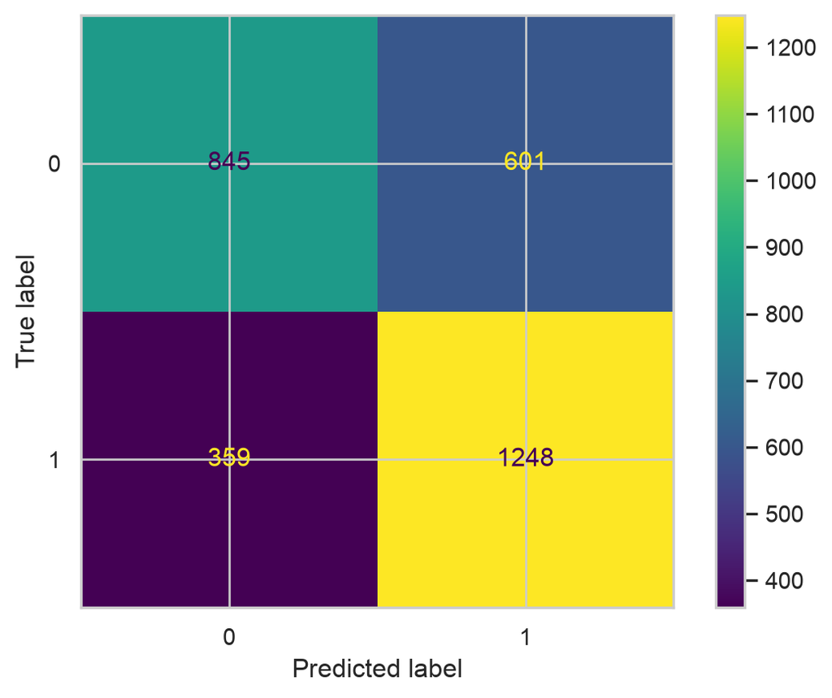

```python
# Generate array of values for confusion matrix
cm = confusion_matrix(y_test, rf_preds, labels=rf1.classes_)

# Plot confusion matrix
disp = ConfusionMatrixDisplay(confusion_matrix=cm,
                             display_labels=rf1.classes_,
                             )
disp.plot(values_format='');
```

The confusion matrix provides a visual representation of the model’s performance on the test data. It shows the counts of true positives, true negatives, false positives, and false negatives, allowing for an assessment of how well the model distinguishes between generous and non-generous tippers.

The model is almost twice as likely to predict a false positive than it is to predict a false negative. Therefore, type I errors are more common. This is less desirable, because it’s better for a driver to be pleasantly surprised by a generous tip when they weren’t expecting one than to be disappointed by a low tip when they were expecting a generous one. However, the overall performance of this model is satisfactory.

### 2.3.28 Feature importance

Use the feature_importances_ attribute of the best estimator object to inspect the features of your final model. You can then sort them and plot the most important ones.

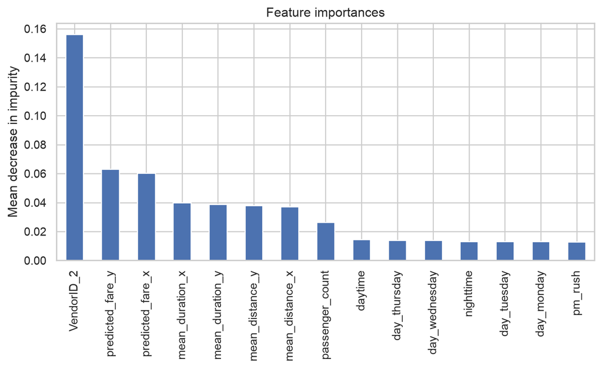

```python
importances = rf1.best_estimator_.feature_importances_
rf_importances = pd.Series(importances, index=X_test.columns)
rf_importances = rf_importances.sort_values(ascending=False)[:15]

fig, ax = plt.subplots(figsize=(8,5))
rf_importances.plot.bar(ax=ax)
ax.set_title('Feature importances')
ax.set_ylabel('Mean decrease in impurity')
fig.tight_layout();
```

# 3 Project 2: Salifort Motors project

**Capstone project: Providing data-driven suggestions for HR**

## 3.1 Assignment instructions: Description and deliverables

This capstone project is an opportunity for you to analyze a dataset and build predictive models that can provide insights to the Human Resources (HR) department of a large consulting firm.

Upon completion, you will have two artifacts that you would be able to present to future employers. One is a brief one-page summary of this project that you would present to external stakeholders as the data professional in Salifort Motors. The other is a complete code notebook provided here. Please consider your prior course work and select one way to achieve this given project question. Either use a regression model or machine learning model to predict whether or not an employee will leave the company. The exemplar following this actiivty shows both approaches, but you only need to do one.

In your deliverables, you will include the model evaluation (and interpretation if applicable), a data visualization(s) of your choice that is directly related to the question you ask, ethical considerations, and the resources you used to troubleshoot and find answers or solutions.

### 3.1.1 Pace: Plan

Consider the questions in your PACE Strategy Document to reflect on the Plan stage.

In this stage, consider the following:

**Understand the business scenario and problem**

The HR department at Salifort Motors wants to take some initiatives to improve employee satisfaction levels at the company. They collected data from employees, but now they don’t know what to do with it. They refer to you as a data analytics professional and ask you to provide data-driven suggestions based on your understanding of the data. They have the following question: what’s likely to make the employee leave the company?

Your goals in this project are to analyze the data collected by the HR department and to build a model that predicts whether or not an employee will leave the company.

If you can predict employees likely to quit, it might be possible to identify factors that contribute to their leaving. Because it is time-consuming and expensive to find, interview, and hire new employees, increasing employee retention will be beneficial to the company.

### 3.1.2 Familiarize ourself with the HR dataset

In this dataset, there are 14,999 rows, 10 columns, and these variables:

#### 3.1.2.1 HR dataset — variable descriptions

[output not shown]

**Reflect on these questions as you complete the plan stage.**

Who are your stakeholders for this project?

What are you trying to solve or accomplish?

What are your initial observations when you explore the data?

What resources do you find yourself using as you complete this stage? (Make sure to include the links.)

Do you have any ethical considerations in this stage?

#### 3.1.2.2 Answering the above questions

**Who are your stakeholders for this project?**

The stakeholders for this project are the HR department at Salifort Motors, as well as the employees of the company. The HR department is interested in improving employee satisfaction and retention, while employees may benefit from a better work environment and job satisfaction.

**What are you trying to solve or accomplish?**

The goal of this project is to analyze the HR dataset and build a predictive model that can identify employees who are likely to leave the company. By understanding the factors that contribute to employee turnover, the HR department can implement strategies to improve retention and job satisfaction.

**What are your initial observations when you explore the data?**

Initial observations from exploring the data may include identifying key features that correlate with employee turnover, such as satisfaction level, last evaluation score, number of projects, and average monthly hours. Additionally, there may be categorical variables like department and salary that could provide insights into employee retention patterns.

**What resources do you find yourself using as you complete this stage? (Make sure to include the links.)**

- [Pandas Documentation](https://pandas.pydata.org/docs/)
- [Scikit-learn Documentation](https://scikit-learn.org/stable/documentation.html)
- [Matplotlib Documentation](https://matplotlib.org/stable/contents.html)
- [Seaborn Documentation](https://seaborn.pydata.org/)

**Do you have any ethical considerations in this stage?**

Yes, there are several ethical considerations to keep in mind during this project. It is important to ensure that employee data is handled with confidentiality and privacy. Any analysis or modeling should avoid biases that could unfairly target specific groups of employees. Additionally, the insights derived from the model should be used to improve employee well-being rather than penalize or discriminate against those who may be identified as likely to leave the company.

#### 3.1.2.3 Data

```python
df0=pd.read_csv("/Users/macbookpro/Training/COURSERA_Data_Analytics/COURSERA_Data_Analytics/Data/HR_capstone_dataset.csv")
df0.head()
```

|  | satisfaction_level | last_evaluation | number_project | average_montly_hours | time_spend_company | Work_accident | left | promotion_last_5years | Department | salary |
| --- | --- | --- | --- | --- | --- | --- | --- | --- | --- | --- |
| 0 | 0.38 | 0.53 | 2 | 157 | 3 | 0 | 1 | 0 | sales | low |
| 1 | 0.80 | 0.86 | 5 | 262 | 6 | 0 | 1 | 0 | sales | medium |
| 2 | 0.11 | 0.88 | 7 | 272 | 4 | 0 | 1 | 0 | sales | medium |
| 3 | 0.72 | 0.87 | 5 | 223 | 5 | 0 | 1 | 0 | sales | low |
| 4 | 0.37 | 0.52 | 2 | 159 | 3 | 0 | 1 | 0 | sales | low |

### 3.1.3 Data inspection

```python
# Gather basic information about the data
df0.info()
```

```
<class 'pandas.DataFrame'>
RangeIndex: 14999 entries, 0 to 14998
Data columns (total 10 columns):
 #   Column                 Non-Null Count  Dtype
---  ------                 --------------  -----
 0   satisfaction_level     14999 non-null  float64
 1   last_evaluation        14999 non-null  float64
 2   number_project         14999 non-null  int64
 3   average_montly_hours   14999 non-null  int64
 4   time_spend_company     14999 non-null  int64
 5   Work_accident          14999 non-null  int64
 6   left                   14999 non-null  int64
 7   promotion_last_5years  14999 non-null  int64
 8   Department             14999 non-null  str
 9   salary                 14999 non-null  str
dtypes: float64(2), int64(6), str(2)
memory usage: 1.1 MB
```

#### 3.1.3.1 Gather descriptive statistics about the data

```python
# Gather descriptive statistics about the data
df0.describe()
```

|  | satisfaction_level | last_evaluation | number_project | average_montly_hours | time_spend_company | Work_accident | left | promotion_last_5years |
| --- | --- | --- | --- | --- | --- | --- | --- | --- |
| count | 14999.000000 | 14999.000000 | 14999.000000 | 14999.000000 | 14999.000000 | 14999.000000 | 14999.000000 | 14999.000000 |
| mean | 0.612834 | 0.716102 | 3.803054 | 201.050337 | 3.498233 | 0.144610 | 0.238083 | 0.021268 |
| std | 0.248631 | 0.171169 | 1.232592 | 49.943099 | 1.460136 | 0.351719 | 0.425924 | 0.144281 |
| min | 0.090000 | 0.360000 | 2.000000 | 96.000000 | 2.000000 | 0.000000 | 0.000000 | 0.000000 |
| 25% | 0.440000 | 0.560000 | 3.000000 | 156.000000 | 3.000000 | 0.000000 | 0.000000 | 0.000000 |
| 50% | 0.640000 | 0.720000 | 4.000000 | 200.000000 | 3.000000 | 0.000000 | 0.000000 | 0.000000 |
| 75% | 0.820000 | 0.870000 | 5.000000 | 245.000000 | 4.000000 | 0.000000 | 0.000000 | 0.000000 |
| max | 1.000000 | 1.000000 | 7.000000 | 310.000000 | 10.000000 | 1.000000 | 1.000000 | 1.000000 |

#### 3.1.3.2 Rename columns

As a data cleaning step, rename the columns as needed. Standardize the column names so that they are all in snake_case, correct any column names that are misspelled, and make column names more concise as needed.

```python
# Display all column names
df0.columns
```

```
Index(['satisfaction_level', 'last_evaluation', 'number_project',
       'average_montly_hours', 'time_spend_company', 'Work_accident', 'left',
       'promotion_last_5years', 'Department', 'salary'],
      dtype='str')
```

```python
# Rename columns as needed
df0 = df0.rename(columns={'Work_accident': 'work_accident',
                          'average_montly_hours': 'average_monthly_hours',
                          'time_spend_company': 'tenure',
                          'Department': 'department'})

# Display all column names after the update
### YOUR CODE HERE ###
df0.columns
```

```
Index(['satisfaction_level', 'last_evaluation', 'number_project',
       'average_monthly_hours', 'tenure', 'work_accident', 'left',
       'promotion_last_5years', 'department', 'salary'],
      dtype='str')
```

#### 3.1.3.3 Check missing values

```python
# Check for missing values
df0.isna().sum()
```

```
satisfaction_level       0
last_evaluation          0
number_project           0
average_monthly_hours    0
tenure                   0
work_accident            0
left                     0
promotion_last_5years    0
department               0
salary                   0
dtype: int64
```

There are no missing values in the data.

#### 3.1.3.4 Check for duplicates

Check for any duplicate entries in the data.

```python
df0.duplicated().sum()
```

```
np.int64(3008)
```

3,008 rows contain duplicates. That is 20% of the data.

```python
# Inspect some rows containing duplicates as needed
df0[df0.duplicated()].head()
```

|  | satisfaction_level | last_evaluation | number_project | average_monthly_hours | tenure | work_accident | left | promotion_last_5years | department | salary |
| --- | --- | --- | --- | --- | --- | --- | --- | --- | --- | --- |
| 396 | 0.46 | 0.57 | 2 | 139 | 3 | 0 | 1 | 0 | sales | low |
| 866 | 0.41 | 0.46 | 2 | 128 | 3 | 0 | 1 | 0 | accounting | low |
| 1317 | 0.37 | 0.51 | 2 | 127 | 3 | 0 | 1 | 0 | sales | medium |
| 1368 | 0.41 | 0.52 | 2 | 132 | 3 | 0 | 1 | 0 | RandD | low |
| 1461 | 0.42 | 0.53 | 2 | 142 | 3 | 0 | 1 | 0 | sales | low |

The above output shows the first five occurences of rows that are duplicated farther down in the dataframe. How likely is it that these are legitimate entries? In other words, how plausible is it that two employees self-reported the exact same response for every column?

You could perform a likelihood analysis by essentially applying Bayes’ theorem and multiplying the probabilities of finding each value in each column, but this does not seem necessary. With several continuous variables across 10 columns, it seems very unlikely that these observations are legitimate. You can proceed by dropping them.

```python
# Drop duplicates and save resulting dataframe in a new variable as needed
df1 = df0.drop_duplicates(keep='first')

# Display first few rows of new dataframe as needed
df1.head()
```

|  | satisfaction_level | last_evaluation | number_project | average_monthly_hours | tenure | work_accident | left | promotion_last_5years | department | salary |
| --- | --- | --- | --- | --- | --- | --- | --- | --- | --- | --- |
| 0 | 0.38 | 0.53 | 2 | 157 | 3 | 0 | 1 | 0 | sales | low |
| 1 | 0.80 | 0.86 | 5 | 262 | 6 | 0 | 1 | 0 | sales | medium |
| 2 | 0.11 | 0.88 | 7 | 272 | 4 | 0 | 1 | 0 | sales | medium |
| 3 | 0.72 | 0.87 | 5 | 223 | 5 | 0 | 1 | 0 | sales | low |
| 4 | 0.37 | 0.52 | 2 | 159 | 3 | 0 | 1 | 0 | sales | low |

#### 3.1.3.5 Check outliers

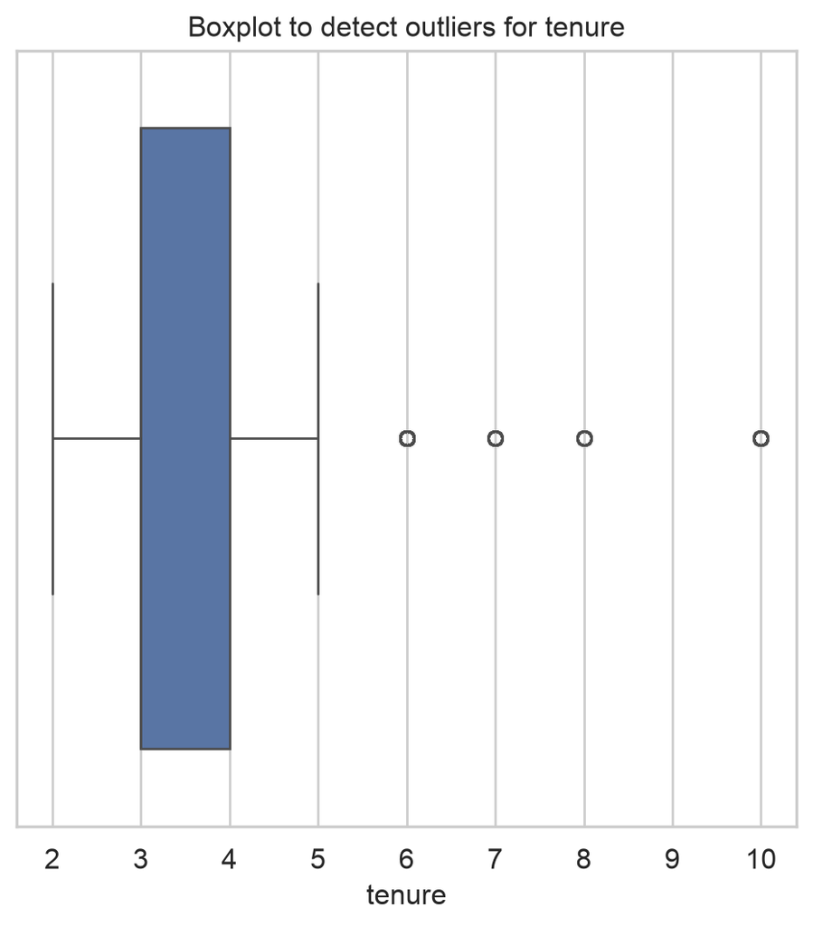

```python
# Create a boxplot to visualize distribution of `tenure` and detect any outliers
plt.figure(figsize=(6,6))
plt.title('Boxplot to detect outliers for tenure', fontsize=12)
plt.xticks(fontsize=12)
plt.yticks(fontsize=12)
sns.boxplot(x=df1['tenure'])
plt.show()
```

There are some outliers in the tenure column. However, these outliers are legitimate values (e.g., an employee could have been with the company for 10 years). Therefore, you will not drop them.

The boxplot above shows that there are outliers in the tenure variable.

It would be helpful to investigate how many rows in the data contain outliers in the tenure column.

```python
# Determine the number of rows containing outliers

# Compute the 25th percentile value in `tenure`
percentile25 = df1['tenure'].quantile(0.25)

# Compute the 75th percentile value in `tenure`
percentile75 = df1['tenure'].quantile(0.75)

# Compute the interquartile range in `tenure`
iqr = percentile75 - percentile25

# Define the upper limit and lower limit for non-outlier values in `tenure`
upper_limit = percentile75 + 1.5 * iqr
lower_limit = percentile25 - 1.5 * iqr
print("Lower limit:", lower_limit)
print("Upper limit:", upper_limit)

# Identify subset of data containing outliers in `tenure`
outliers = df1[(df1['tenure'] > upper_limit) | (df1['tenure'] < lower_limit)]

# Count how many rows in the data contain outliers in `tenure`
print("Number of rows in the data containing outliers in `tenure`:", len(outliers))
```

```
Lower limit: 1.5
Upper limit: 5.5
Number of rows in the data containing outliers in `tenure`: 824
```

Certain types of models are more sensitive to outliers than others. When you get to the stage of building your model, consider whether to remove these outliers based on the type of model you decide to use.

### 3.1.4 Analyze stage

**Reflect on these questions as you complete the analyze stage.**

What did you observe about the relationships between variables?

What do you observe about the distributions in the data?

What transformations did you make with your data? Why did you chose to make those decisions?

What are some purposes of EDA before constructing a predictive model?

What resources do you find yourself using as you complete this stage? (Make sure to include the links.)

Do you have any ethical considerations in this stage?

#### 3.1.4.1 Answering the above questions

**What did you observe about the relationships between variables?**

During the exploratory data analysis (EDA), I observed several relationships between variables. For instance, there appeared to be a correlation between satisfaction level and the likelihood of an employee leaving the company. Employees with lower satisfaction levels were more likely to leave. Additionally, the number of projects and average monthly hours also seemed to influence employee turnover, with those working on more projects or longer hours being more prone to leaving.

**What do you observe about the distributions in the data?**

The distributions of several variables, such as satisfaction level and last evaluation scores, were skewed. This skewness indicated that a majority of employees had high satisfaction and evaluation scores, while a smaller portion had lower scores. The tenure variable also showed a right-skewed distribution, with most employees having shorter tenures and a few having very long tenures.

**What transformations did you make with your data? Why did you chose to make those decisions?**

I made several transformations to the data to prepare it for modeling. For example, I converted categorical variables like department and salary into dummy variables to facilitate their use in the model. I also scaled continuous variables to ensure that they were on a similar scale, which is important for certain machine learning algorithms. Additionally, I addressed outliers in the tenure variable by considering their potential impact on the model and deciding whether to include or exclude them based on the model type.

**What are some purposes of EDA before constructing a predictive model?**

Exploratory Data Analysis (EDA) serves several important purposes before constructing a predictive model. It helps to understand the underlying structure and relationships within the data, identify potential issues such as missing values or outliers, and assess the distributions of variables. EDA also aids in feature selection and engineering by revealing which variables may be most relevant for the model. Overall, EDA provides insights that inform the modeling process and helps ensure that the model is built on a solid foundation.

**What resources do you find yourself using as you complete this stage? (Make sure to include the links.)**

- [Pandas Documentation](https://pandas.pydata.org/docs/)
- [Seaborn Documentation](https://seaborn.pydata.org/)
- [Matplotlib Documentation](https://matplotlib.org/stable/contents.html)
- [Scikit-learn Documentation](https://scikit-learn.org/stable/documentation.html)

**Do you have any ethical considerations in this stage?**

Yes, there are ethical considerations to keep in mind during the EDA stage. It is important to ensure that the analysis does not inadvertently introduce bias or discrimination, especially when dealing with sensitive employee data. Care should be taken to respect employee privacy and confidentiality, and any insights derived from the data should be used to improve employee well-being rather than penalize or discriminate against certain groups. Additionally, transparency about the methods and findings is crucial to maintain trust with stakeholders.

### 3.1.5 Data Exploration (Continue EDA)

Begin by understanding how many employees left and what percentage of all employees this figure represents.

```python
# Get numbers of people who left vs. stayed
print(df1['left'].value_counts())
print()

# Get percentages of people who left vs. stayed
print(df1['left'].value_counts(normalize=True))
```

```
left
0    10000
1     1991
Name: count, dtype: int64

left
0    0.833959
1    0.166041
Name: proportion, dtype: float64
```

#### 3.1.5.1 Data visualizations

Now, examine variables that you’re interested in, and create plots to visualize relationships between variables in the data.

We could start by creating a stacked boxplot showing average_monthly_hours distributions for number_project, comparing the distributions of employees who stayed versus those who left.

Box plots are very useful in visualizing distributions within data, but they can be deceiving without the context of how big the sample sizes that they represent are. So, you could also plot a stacked histogram to visualize the distribution of number_project for those who stayed and those who left.

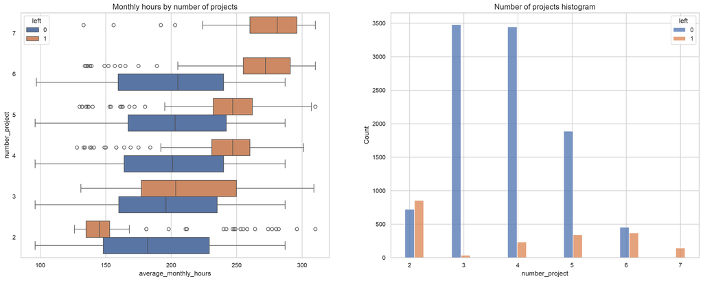

```python
# Create a plot as needed

# Set figure and axes
fig, ax = plt.subplots(1, 2, figsize = (22,8))

# Create boxplot showing `average_monthly_hours` distributions for `number_project`, comparing employees who stayed versus those who left
sns.boxplot(data=df1, x='average_monthly_hours', y='number_project', hue='left', orient="h", ax=ax[0])
ax[0].invert_yaxis()
ax[0].set_title('Monthly hours by number of projects', fontsize='14')

# Create histogram showing distribution of `number_project`, comparing employees who stayed versus those who left
tenure_stay = df1[df1['left']==0]['number_project']
tenure_left = df1[df1['left']==1]['number_project']
sns.histplot(data=df1, x='number_project', hue='left', multiple='dodge', shrink=2, ax=ax[1])
ax[1].set_title('Number of projects histogram', fontsize='14')

# Display the plots
plt.show()
```

The boxplot and histogram above provide insights into the relationship between the number of projects an employee is involved in and their average monthly hours, as well as how these factors differ between employees who stayed and those who left the company.

It might be natural that people who work on more projects would also work longer hours. This appears to be the case here, with the mean hours of each group (stayed and left) increasing with number of projects worked. However, a few things stand out from this plot.

There are two groups of employees who left the company: (A) those who worked considerably less than their peers with the same number of projects, and (B) those who worked much more. Of those in group A, it’s possible that they were fired. It’s also possible that this group includes employees who had already given their notice and were assigned fewer hours because they were already on their way out the door. For those in group B, it’s reasonable to infer that they probably quit. The folks in group B likely contributed a lot to the projects they worked in; they might have been the largest contributors to their projects.

Everyone with seven projects left the company, and the interquartile ranges of this group and those who left with six projects was ~255–295 hours/month—much more than any other group.

The optimal number of projects for employees to work on seems to be 3–4. The ratio of left/stayed is very small for these cohorts.

If you assume a work week of 40 hours and two weeks of vacation per year, then the average number of working hours per month of employees working Monday–Friday = 50 weeks * 40 hours per week / 12 months = 166.67 hours per month. This means that, aside from the employees who worked on two projects, every group—even those who didn’t leave the company—worked considerably more hours than this. It seems that employees here are overworked.

As the next step, you could confirm that all employees with seven projects left.

```python
# Get value counts of stayed/left for employees with 7 projects
df1[df1['number_project']==7]['left'].value_counts()
```

```
left
1    145
Name: count, dtype: int64
```

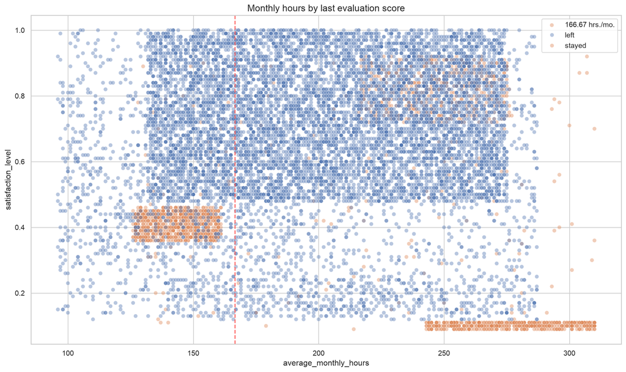

```python
# Create a plot as needed

# Create scatterplot of `average_monthly_hours` versus `satisfaction_level`, comparing employees who stayed versus those who left
plt.figure(figsize=(16, 9))
sns.scatterplot(data=df1, x='average_monthly_hours', y='satisfaction_level', hue='left', alpha=0.4)
plt.axvline(x=166.67, color='#ff6361', label='166.67 hrs./mo.', ls='--')
plt.legend(labels=['166.67 hrs./mo.', 'left', 'stayed'])
plt.title('Monthly hours by last evaluation score', fontsize='14');
```

The scatterplot above shows that there was a sizeable group of employees who worked ~240–315 hours per month. 315 hours per month is over 75 hours per week for a whole year. It’s likely this is related to their satisfaction levels being close to zero.

The plot also shows another group of people who left, those who had more normal working hours. Even so, their satisfaction was only around 0.4. It’s difficult to speculate about why they might have left. It’s possible they felt pressured to work more, considering so many of their peers worked more. And that pressure could have lowered their satisfaction levels.

Finally, there is a group who worked ~210–280 hours per month, and they had satisfaction levels ranging ~0.7–0.9.

Note the strange shape of the distributions here. This is indicative of data manipulation or synthetic data.

For the next visualization, it might be interesting to visualize satisfaction levels by tenure.

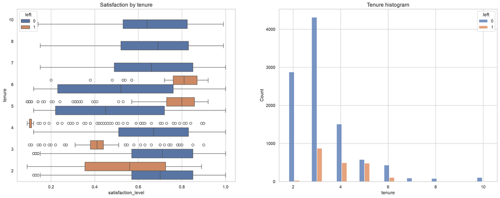

```python
# Create a plot as needed

# Set figure and axes
fig, ax = plt.subplots(1, 2, figsize = (22,8))

# Create boxplot showing distributions of `satisfaction_level` by tenure, comparing employees who stayed versus those who left
sns.boxplot(data=df1, x='satisfaction_level', y='tenure', hue='left', orient="h", ax=ax[0])
ax[0].invert_yaxis()
ax[0].set_title('Satisfaction by tenure', fontsize='14')

# Create histogram showing distribution of `tenure`, comparing employees who stayed versus those who left
tenure_stay = df1[df1['left']==0]['tenure']
tenure_left = df1[df1['left']==1]['tenure']
sns.histplot(data=df1, x='tenure', hue='left', multiple='dodge', shrink=5, ax=ax[1])
ax[1].set_title('Tenure histogram', fontsize='14')

plt.show();
```

The boxplot and histogram above provide insights into the relationship between employee satisfaction levels and tenure, as well as how these factors differ between employees who stayed and those who left the company.

There are many observations you could make from this plot.

Employees who left fall into two general categories: dissatisfied employees with shorter tenures and very satisfied employees with medium-length tenures.

Four-year employees who left seem to have an unusually low satisfaction level. It’s worth investigating changes to company policy that might have affected people specifically at the four-year mark, if possible.

The longest-tenured employees didn’t leave. Their satisfaction levels aligned with those of newer employees who stayed.

The histogram shows that there are relatively few longer-tenured employees. It’s possible that they’re the higher-ranking, higher-paid employees.

As the next step in analyzing the data, you could calculate the mean and median satisfaction scores of employees who left and those who didn’t.

```python
# Calculate mean and median satisfaction scores of employees who left and those who stayed
df1.groupby(['left'])['satisfaction_level'].agg([np.mean,np.median])
```

| left | mean | median |
| --- | --- | --- |
| 0 | 0.667365 | 0.69 |
| 1 | 0.440271 | 0.41 |

As expected, the mean and median satisfaction scores of employees who left are lower than those of employees who stayed. Interestingly, among employees who stayed, the mean satisfaction score appears to be slightly below the median score. This indicates that satisfaction levels among those who stayed might be skewed to the left.

Next, you could examine salary levels for different tenures.

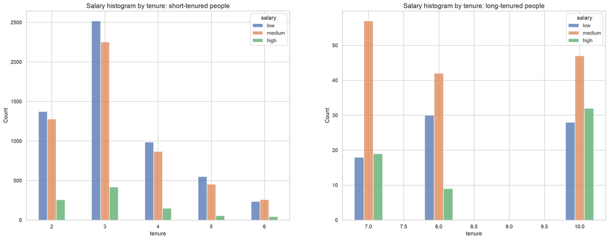

```python
# Create a plot as needed
# Set figure and axes
fig, ax = plt.subplots(1, 2, figsize = (22,8))

# Define short-tenured employees
tenure_short = df1[df1['tenure'] < 7]

# Define long-tenured employees
tenure_long = df1[df1['tenure'] > 6]

# Plot short-tenured histogram
sns.histplot(data=tenure_short, x='tenure', hue='salary', discrete=1,
             hue_order=['low', 'medium', 'high'], multiple='dodge', shrink=.5, ax=ax[0])
ax[0].set_title('Salary histogram by tenure: short-tenured people', fontsize='14')

# Plot long-tenured histogram
sns.histplot(data=tenure_long, x='tenure', hue='salary', discrete=1,
             hue_order=['low', 'medium', 'high'], multiple='dodge', shrink=.4, ax=ax[1])
ax[1].set_title('Salary histogram by tenure: long-tenured people', fontsize='14');
```

The plots above show that long-tenured employees were not disproportionately comprised of higher-paid employees.

Next, you could explore whether there’s a correlation between working long hours and receiving high evaluation scores. You could create a scatterplot of average_monthly_hours versus last_evaluation.

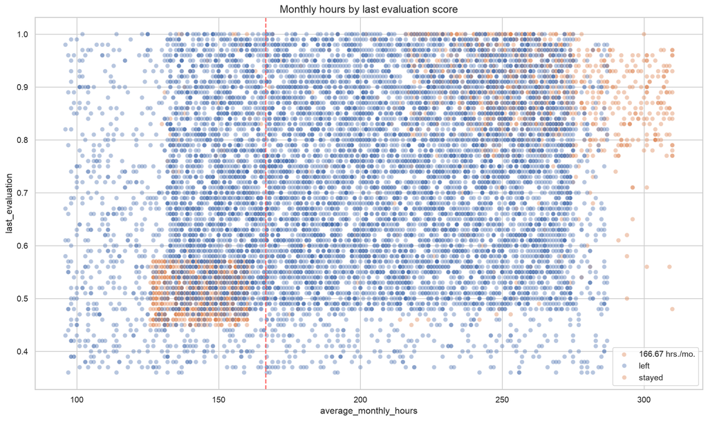

```python
# Create a plot as needed
# Create scatterplot of `average_monthly_hours` versus `last_evaluation`
plt.figure(figsize=(16, 9))
sns.scatterplot(data=df1, x='average_monthly_hours', y='last_evaluation', hue='left', alpha=0.4)
plt.axvline(x=166.67, color='#ff6361', label='166.67 hrs./mo.', ls='--')
plt.legend(labels=['166.67 hrs./mo.', 'left', 'stayed'])
plt.title('Monthly hours by last evaluation score', fontsize='14');
```

The scatterplot above shows that there isn’t a strong correlation between working long hours and receiving high evaluation scores. Employees who worked longer hours did not consistently receive higher evaluation scores, and vice versa.

There are employees who worked very long hours but received low evaluation scores. This suggests that simply working longer hours does not guarantee better performance evaluations.